REVIEW

Open Access

The use of mesenchymal stem cells for

cartilage repair and regeneration:

a systematic review

Andy Goldberg<sup>1</sup>, Katrina Mitchell<sup>1</sup>, Julian Soans<sup>1</sup>, Louise Kim<sup>2</sup>and Razi Zaidi<sup>1*</sup>

Abstract

Background: The management of articular cartilage defects presents many clinical challenges due to its avascular,

aneural and alymphatic nature. Bone marrow stimulation techniques, such as microfracture, are the most frequently

used method in clinical practice however the resulting mixed fibrocartilage tissue which is inferior to native hyaline

cartilage. Other methods have shown promise but are far from perfect. There is an unmet need and growing

interest in regenerative medicine and tissue engineering to improve the outcome for patients requiring cartilage

repair. Many published reviews on cartilage repair only list human clinical trials, underestimating the wealth of basic

sciences and animal studies that are precursors to future research. We therefore set out to perform a systematic

review of the literature to assess the translation of stem cell therapy to explore what research had been carried out

at each of the stages of translation from bench-top (in vitro), animal (pre-clinical) and human studies (clinical) and

assemble an evidence-based cascade for the responsible introduction of stem cell therapy for cartilage defects.

Main body of abstract: This review was conducted in accordance to PRISMA guidelines using CINHAL, MEDLINE,

EMBASE, Scopus and Web of Knowledge databases from 1st January 1900 to 30th June 2015. In total, there were

studies both of terms of animal used, location of harvest (fat, marrow, blood or synovium) and allogeneicity. The

use of scaffolds, growth factors, number of cell passages and number of cells used was hugely heterogeneous.

Short conclusions: This review offers a comprehensive assessment of the evidence behind the translation of

basic science to the clinical practice of cartilage repair. It has revealed a lack of connectivity between the in vitro,

pre-clinical and human data and a patchwork quilt of synergistic evidence. Drivers for progress in this space are

largely driven by patient demand, surgeon inquisition and a regulatory framework that is learning at the same pace

as new developments take place.

Keywords: Matrix-induced autologous chondrocyte implantation, Autologous chondrocyte implantation,

Mesenchymal stem cells

Background

Articular cartilage is a highly specialised tissue acting as

a shock absorber, enabling synovial joints to articulate

with low frictional forces. Due to its avascular, aneural

and alymphatic state, it has a limited repair potential [1].

Surgical options to manage damaged articular cartilage

include arthroscopic debridement [2–5], bone marrow

stimulation techniques [6–8], chondrocyte implantation

[9–13], osteochondral autografts (mosaicplasty) [2, 14, 15],

osteochondral allograft [16–18] and, in the presence of

osteoarthritis, joint replacement [19].

Bone marrow stimulation techniques, such as micro-

fracture, are the most frequently used method in clinical

practice for treating small symptomatic lesions of the

articular cartilage [6–8]. However, the resulting tissue

has shown to be a mixed fibrocartilage tissue [20–22]

with varying amounts of type II collagen [8, 21, 23, 24]

and inferior to native hyaline cartilage. Fibrocartilage is

[figure not shown]

vulnerable to shear stresses and prone to breaking down

over time [20]. Subchondral osseous overgrowth has also

been reported after microfracture [25, 26]. Osteochon-

dral grafts can lead to donor site morbidity and healing

seams at the recipient site [27, 28]. Autologous chondro-

cyte implantation (ACI) [9, 10] and its later evolution,

matrix-induced

autologous

chondrocyte

implantation

(MACI), offered great promise with 80% of patients

showing good or excellent results at 10 years [29] but at

best results in hyaline-like repair and has experienced

complications such as graft failure, periosteal hyper-

trophy and delamination [30, 31]. In addition, it has also

been reported that cells may lose their phenotype during

expansion [32, 33].

There is therefore a growing interest in regenerative

medicine, which can broadly be thought of as two main

types: cell therapy, where cells are injected directly into

the blood or into tissues, and tissue engineering, where

cell-scaffold combinations are used to repair or regener-

ate tissues.

Stem cells are cells that have the ability to divide and

develop into many different cell types in the body and

can be categorised as pluripotent and multipotent. Pluri-

potent stem cells are often harvested from embryonic

sources and can develop into any type of cell in the body

whereas multipotent stem cells are generally taken from

adults and can divide and develop into a more limited

range of cell types. When stem cells divide, the new cells

can either remain stem cells or develop into a new type

of cell with a more specific function (Table 1).

Mesenchymal

stem

cells

(MSCs)

are

a

form

of

multipotent cells that may offer an alternative to cartil-

age repair techniques not hampered by availability and

donor site morbidity.

The introduction of stem cell therapies into clinical

practice however is a form of translational research,

which as per any “bench-to-bedside” pathway now has

enormous governance issues [34, 35] and is highly regu-

latory across four phases (Table 2) and by the Tissues

and

Cells

Directive

(2004/23/EC)

https://www.hta.

gov.uk/policies/eu-tissue-and-cells-directives.

Many published reviews on cartilage repair only list

human clinical trials [13, 36–46], underestimating the

wealth of basic sciences and animal studies that are pre-

cursors to future research and may be relevant in clinical

practice further down the line. In addition, true transla-

tion would imply that all of the clinical studies would

have supporting pre-clinical data.

We therefore set out to perform a systematic review of

the literature to assess the translation of stem cell

therapy to explore what research had been carried out at

each of the stages of translation from bench-top (in

vitro), animal (pre-clinical), and human studies (clinical)

and assemble an evidence-based cascade for the respon-

sible introduction of stem cell therapy for cartilage

defects. In particular, we wanted to focus on the key

burning questions pertaining to cartilage repair such as

cell source, dosage (how many cells should be used),

requirement for scaffolds and the role for extrinsic

growth factors.

Main text

Search methodology

This review was conducted in accordance to PRISMA

guidelines [47] using CINHAL, MEDLINE, EMBASE,

Scopus and Web of Knowledge databases from 1st

January 1900 to 30th June 2015.

The keywords used in the selection were “(“mesenchy-

mal stem cells”[All Fields] OR “mesenchymal stem

cells”[MeSH Terms] OR “mesenchymal”[All Fields] OR

“stem cells”[All Fields] OR “Stem Cells”[MeSH Terms]

OR “MSC”[All Fields]) AND (“Articular Cartilage”[MeSH

Terms]

OR

“articular”[All

Fields]

OR

“cartilage”[All

Fields] OR “cartilage”[MeSH Terms]) AND (“healing”[All

Terms] OR “repair”[All Terms] OR “Regeneration”[MeSH

Terms] OR “regeneration”[All Fields] OR “tissue engi-

neering”[MeSH Terms] OR “tissue engineering”[All

Fields]) AND (“defect”[All Terms]) AND (“chond*”[All

Terms])”.

All review and non-English studies were excluded. For

analysis, only original research studies were included.

Any duplicates were excluded. Initially, KM and JS inde-

pendently screened studies’ title and abstract. Those

Table 1 Table describing the three main properties of stem cells

Stem cell properties

• They are unspecialized (“blank slates” that can become specific

types of cells).

• They can develop into specialized cell types (cells that do specific

work in the body).

• They are capable of surviving over long periods and divide to make

additional stem cells.

Table 2 Description of the different phases of clinical trials

Clinical trial phases (http://www.nlm.nih.gov/services/ctphases.html)

Phase I: Safety Studies or First-In-Man. Researchers test a new drug or

treatment in a small group of people for the first time to evaluate its

safety, determine a safe dosage range, and identify side effects.

Phase II: Uncontrolled Efficacy Studies. The drug or treatment is given

to a larger group of people to see if it is effective and to further

evaluate its safety.

Phase III: Randomised Clinical Trials. The drug or treatment is given to

large groups of people to confirm its effectiveness, monitor side

effects, compare it to commonly used treatments, and collect

information that will allow the drug or treatment to be used safely.

Phase IV: Post-Market Surveillance. Studies are done after the drug or

treatment has been marketed to gather information on the drug’s

effect in various populations and any side effects associated with

long-term use.

included had the full text reviewed. Any disparities were

discussed with the senior author (AJG). The references

of eligible studies were also searched and included where

relevant.

Unpublished trial databases (e.g. ClinicalTrials.gov)

were reviewed as the grey literature using popular search

engines, including Google.

The keywords used for

registered clinical trials in clinical trial databases were

“stem cells”, “cartilage” and “orthopaedics”.

Eligible studies were drafted into tables tabulating the

key data.

Results

The initial search identified 2880 study articles, of which

In vitro studies

MSC source A list of cell sources used in the in vitro

studies is shown in Table 3. The commonest being

human MSCs (66%) followed by rabbit MSCs (15%). The

used commercial cell lines [48, 49].

Scaffold Within the in vitro studies, 26 different types

of natural scaffold and 9 types of synthetic scaffolds were

identified with a further 18 different types of hybrids,

(Table 4).

Growth factors The commonest used growth factors

were TGF-β and the bone morphogenetic protein (BMP)

family. A list of growth factors used can be seen in

Table 5.

Cell seeding and passage There was wide heterogeneity

in cell seeding density and there appeared to be no

standard form of measurement. Li et al. [50] examined

three different seeding densities: 2, 5 and 10 × 10<sup>6</sup>cells/

scaffold, and found that scaffolds seeded with 5 × 10<sup>6</sup>

cells per scaffold induced the highest chondrogenesis;

however, other groups [51–53] found that a higher

seeding density results in better chondrogenesis.

Apart from 26 studies which did not state cell passage

number, most studies used MSC of an early passage,

anything between uncultured fresh (passage zero (P0)

and five times passaged cells (P5). One study used cells

of P6 [54], and another study used cells between P4 and

P7 [48]. No relationship was apparent between chondro-

genesis and number of passages.

Length of study The length of each in vitro study can

be seen in Table 6. The majority of studies were short-

term models; 27 studies (25%) ended between 1 and

Method of assessment A range of techniques was used

to assess chondrogenesis within the in vitro studies.

These techniques consisted of histology, immunohisto-

chemistry, qPCR, biochemical analysis, imagery and

mechanical testing. The techniques used are summarised

in Table 7.

Animal studies (pre-clinical)

One hundred eleven animal studies were included of

which 109 were controlled laboratory studies, one was a

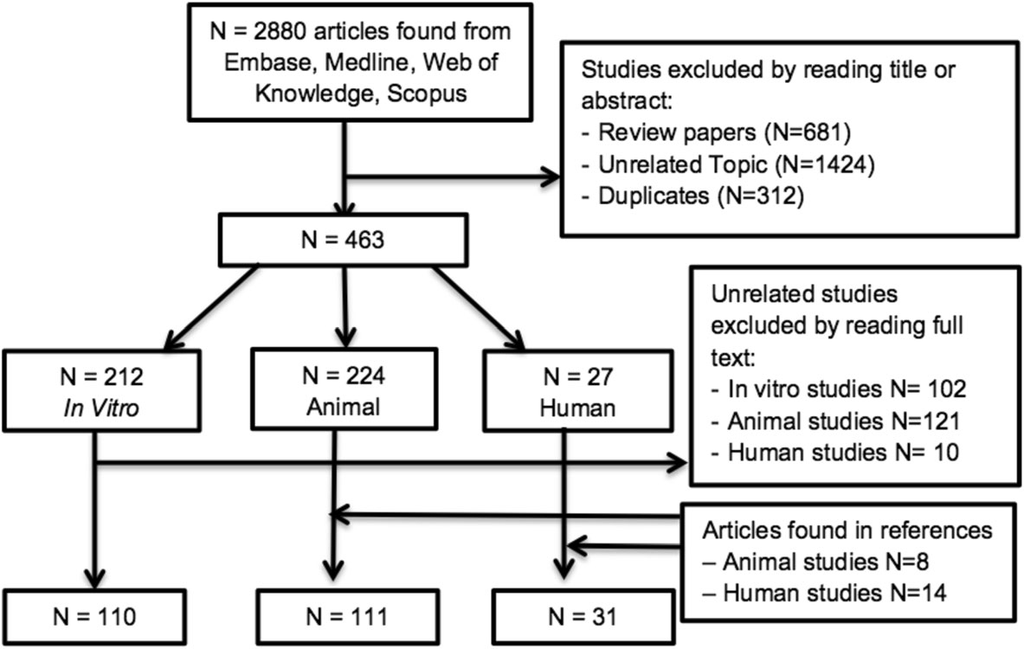

Fig. 1 Flow chart of literature search used for the review

pilot study [49] and one was a longitudinal case study

on a race horse [55]. The commonest animal studied

Defect The size of the defect varied from 2 to 25 mm<sup>2</sup>

in the smaller animals and from 1 to 64 mm<sup>2</sup>in the

larger animals. All but two studies [56, 57] used the knee

for defect creation.

Stem cell type Bone marrow-derived stem cells were

used in 84 studies (75%). Thirteen studies (11%) used

adipose stem cells [54, 58–69], six (5%) used synovia

[70–75] and three (2%) used periostium-derived MSCs

[76–78]. Three studies (3%) used embryonic stem cell-

derived MSCs [79–81] whereas 2 studies (2%) used

muscle-derived MSCs [82, 83]. One group showed

promising results of allogenic MSCs in a rabbit model

when compared to autologous cells, although numbers

were small [84, 85]. Another used compared autologous

chondroprogenitor cells and allogenic chondroprogeni-

tor cells against controls in an equine model and

reported that repair tissue quality in the allogenic cell

group was not superior to that in the control (fibrin

only)

group

and

also

showed

poorer

radiographic

changes in the allogenic group [23].

Cell culture, dose and delivery There was much vari-

ation in the number of cells implanted and the number

of cell passages from 3–10 or more [79, 86].

The number of cells varied from 4 × 10<sup>3</sup>– 1 × 10<sup>10</sup>.

The majority of studies used between 10<sup>6</sup>and 10<sup>8</sup>

cells.

Some

did

not

specify

the

number

of

cells

implanted.

Two

studies

suggested

that

improved

chondrogenesis occurs with a higher implanted cell

number [75, 87], although others suggested that the high

cell numbers increase the risk of synovitis [75] and

synovial proliferation [88].

The cells were transplanted into the defect both as

cell therapy (injection directly into the joint) (17

studies, 15%) or by tissue engineering (cell-scaffold

combinations) (94 studies, 85%). Fifteen studies [49, 65,

72, 75, 81, 86, 89–97] used a mixture of solutions pre-

pared from hyaluronic acid [65, 92, 94–97], phosphate

buffer solution [91], plasma [75], basal medium with

chondrogenesis [89], collagen acid [93], sodium alginate

[86] or a growth factor medium [90]. Two studies used

MSCs only [49, 72].

Scaffold Ninety-two studies (82%) used a scaffold. The

material used was a synthetic polymer either collagen

based, fibrinogen glue or a synthetic protein (e.g.

rHuBMP-2) in 62 (56%) studies (Table 9).

Growth factors Thirty-two studies (29%) assessed the

effect of growth factors on MSC chondrogenesis. Seven-

jority of which show a positive effect on chondrogenesis.

Associated procedures Ten of the studies compared

MSC treatment against other surgical modalities such as

debridement [55], microfracture [49, 91, 96, 98, 99] and

mosaicplasty [77, 100–102].

Outcome measures There were a variety of outcome

measures used to analyse the results of the studies. The

majority of studies (79%) used evidence of hyaline-like

cartilage as being a positive outcome (Tables 11 and 12).

Table 3 Cell species and cell sources

Cell species

No. of

studies

References

Cell Source

No. of

studies<sup>a</sup>

References

Human

73

[48, 50, 52, 53, 168–236]

Bone marrow

62

[48, 50–53, 164, 168, 170–173, 177–180, 182–185,

187, 188, 192, 195–197, 203, 206–210, 212, 216,

217, 219, 221, 223, 227, 230, 232–235, 237–255]

Rabbit

17

[240–242, 246, 249, 252, 255–265]

Adipose

36

[66, 169, 175, 176, 181, 186, 189, 193, 194, 199,

201, 202, 211, 214, 216, 218–220, 224, 228, 229,

231, 235, 242, 256, 257, 260–269]

Bovine

5

[51, 164, 243, 245, 270]

Synovium

9

[174, 191, 200, 213, 222, 226, 258, 259, 270]

Rat/mouse

5

[239, 250, 266, 269, 271]

Umbilical cord blood

3

[205, 236, 190]

Porcine

3

[247, 248, 268]

Commercial cell line

2

[215, 271]

Equine

3

[238, 253, 254]

Placental

2

[198, 225]

Goat

1

[244]

Embryonic

1

[216]

Ovine

2

[237, 251]

Not stated

0

Not stated

1

[267]

aSome studies used cells from more than one cell source

Human studies (clinical)

Thirty-one published studies by 15 different groups

looked at clinical applications of MSCs. One used allo-

genic stem cells [103] and the rest autologous stem cells.

The types of studies can be seen in Tables 13 and 14.

There were 52 unpublished clinical trials, majority of

which are early phase studies (I–II; 63%) and only 5

trials were phase II/III. Table 15 shows a summary of

these clinical trials.

Defects The majority of studies (42%) used MSCs to

treat knee osteoarthritis [103–115]. The rest of the

studies looked at knee cartilage defects except for two

which studied the ankle talar dome [116, 117]. One

study used MSCs to treat knee osteoarthritis (OA), knee

OA and ankle OA [112].

Of the knee cartilage defects, the patients were

heterogeneous with varying defect sizes and locations,

including the patellae [118–121], patella-femoral joints

[122, 123], femoral condyle [113, 119–121, 123–132],

trochlear [119–121] and tibial plateau [121]; and several

had multiple defect sites [105, 120, 123, 128].

Previous treatment and associated procedures The

majority of patients who received MSC treatment had

undergone previous arthroscopy [103, 104, 118, 119,

122, 124, 130], failed debridement [113, 118, 119,

Table 4 Types of scaffolds

Number of studies using types of scaffold

Natural

Synthetic

Hybrid

Growth factor

combined

None

used

47

14

22

6

29

Scaffold

No. of

studies

References

Types of scaffolds used

Natural scaffolds

Type I collagen hydrogel

6

[185, 190, 211, 226,

241, 251]

Agarose hydrogel

4

[53, 247, 248, 268]

Alginate bead

3

[223, 231, 271]

Fibrin hydrogel

3

[208, 211, 263]

Silk fibroin

3

[198, 216, 256]

Chitosan microspheres

2

[260, 262]

Hyaluronic acid

2

[195, 237]

Cartilage-derived matrix

2

[193, 238]

K-carrageenan

2

[169, 199]

Chitosan

2

[168, 216]

Hyaluronic acid hydrogel

2

[164, 245]

Gelatin-based scaffold

2

[176, 233]

Devitalised cartilage ECM

1

[220]

Bead in bead alginate polysaccharide capsules

1

[221]

Atelocollagen gel

1

[225]

Fibrin disk

1

[254]

Methacrylated hyaluronic acid

1

[164]

Gelatin microspheres

1

[260]

Decellularised cell matrix

1

[191]

Collagen type I microspheres

1

[52]

Alginate microbeads

1

[266]

Alginate disks

1

[270]

Platelet rich plasma

1

[242]

Free oligosaccharide chondroitin sulphate C

1

[205]

Collagen type I sponge

1

[237]

3D printed chitosan

1

[181]

Synthetic scaffolds

Polycaprolactone

3

[197, 207, 209]

PLGA

3

[194, 204, 257]

Polylactic acid

2

[230, 232]

PVA

1

[244]

PGA

1

[178]

Poly-DL-lactide-co-glycolide

1

[194]

Polylactide-co-caprolactone

1

[214]

GFOGER modified PEG hydrogel

1

[183]

OPF hydrogel

1

[240]

Hybrid scaffolds

Fibrin–polurethane hydrogel

4

[50, 188, 192, 267]

Esterified hyaluronan and gelatin polymer

2

[212, 255]

TruFit CB (PLGA, calcium sulphate and

polycolide)

1

[187]

Table 4 Types of scaffolds (Continued)

PCL–HA bilayer

1

[243]

PEGDG–crosslinked hyaluronic acid

1

[202]

Polylactic acid–alginate

1

[232]

Sodium alginate–hyaluronic acid

1

[189]

Chitosan–collagen type I

1

[258]

Polyvinylalcohol–polycaprolactone

1

[246]

Tricalcium phosphate-collagen-hyaluronan

1

[180]

Poly-L-lactic acid–hydroxyapatite

1

[215]

Collagen type I–polylactic acid

1

[217]

Polylactic acid–polyglycolic acid with fibrin

1

[261]

Collagen–polyglycolic acid

1

[252]

Chondroitin sulphate C–collagen type II

1

[236]

Fibrin hydrogel with chondroitin sulphate

1

[263]

Chitosan-demineralised bone matrix

1

[239]

Alginate foam-chondroitin sulphate

1

[170]

Growth factor combined with scaffolds

TGF-β1-loaded microspheres with chitosan

microspheres

1

[262]

TGF-β1 releasing chitosan-collagen hydrogel

1

[174]

PEOT/PBT TGF-β1 loaded scaffolds

1

[173]

TGF-β1-activated chitosan/gelatin

1

[249]

PLGA nanospheres with TGF-β1

1

[172]

TGF-β1 loaded Gelatin Microspheres

1

[175]

121–123, 125, 127, 131] or bone marrow stimulation

[114, 116, 117, 126].

terior superior iliac spine [103–105, 109, 111–113,

used adipose-derived MSCs [106–108, 110, 114], two

studies (7%) used synovium-derived MSCs [129, 133]

and two studies (7%) used peripheral blood progenitor

cells collected by apheresis [119, 121].

Cell stage Twenty

studies

(61%)

culture-expanded

their cells [103–105, 107–113, 115, 118, 120, 122–

126, 129, 133], whereas 11 studies (39%) used fresh

concentrated stem cells from bone marrow [116, 117,

127, 128, 130–132], fat tissues [106, 114] or periph-

eral blood [119, 121] in a one stage-procedure. In

studies using bone marrow concentrate, approximately

60 ml of bone marrow aspirate was harvested and

concentrated down to a volume of 2–4 ml before use

[116, 117, 127, 130–132]. In studies using culture-

expanded cells, the majority used cells from early

passages, P1–P3 [103, 105, 109, 110, 112, 113, 115,

118, 120, 122–125, 129]. One study reported the use

of cells at a late passage (P5) [104] ,and five studies

did not specify a passage number [107, 108, 111,

126, 133].

Thirteen studies (42%) confirmed the phenotype of

cells before clinical application [105, 108–110, 112, 115,

119,

120,

122–125,

129].

Commonly

used

surface

markers to select MSCs were CD29, CD44, CD73, CD90

and CD105. Also CD14, CD34 and HLA-DR were used

to eliminate non-MSCs.

Cell dose and delivery The number of cells applied

(dose) varied from 2–57 million for bone marrow-derived

Table 5 Number of in vitro studies using different growth factors

Growth factor

No. of

studies (%)

References

Growth factor

No. of

studies (%)

References

TGF-β1

48 (44%)

[50, 169–175, 189, 190, 192, 193, 195, 199, 202,

208, 210, 211, 213, 214, 216, 217, 220, 222–224,

228, 230–232, 234, 235, 244, 246, 249, 252–256,

258, 260–263, 266, 267, 270]

SOX-5

1 (1%)

[204]

TGF-β3

32 (29%)

[51, 162, 164, 168, 177, 181–184, 197, 200, 205–207,

218, 223–225, 227, 237, 239, 240, 245, 247, 248,

250, 251, 257, 259, 267, 268, 270]

SOX-6

1 (1%)

[204]

BMP-2

13 (12%)

[188, 202, 213, 219, 225–227, 229, 264, 265,

267, 270, 271]

WNT3A

1 (1%)

[171]

FGF

9 (8%)

[171, 183, 193, 197, 198, 213, 225, 246, 258]

IL-1

1 (1%)

[197]

IGF-1

7 (6%)

[179, 184, 192, 213, 224, 254, 265]

EGF

1(1%)

[193]

BMP-6

7 (6%)

[181, 216, 219, 224, 227, 250, 266]

OP-1

1 (1%)

[222]

TGF-β2

4 (4%)

[209, 219, 238, 270]

AA2P

1 (1%)

[266]

GDF-5

3 (3%[

[48, 186, 269]

IL-10

1 (1%)

[178]

SOX-9

2 (2%)

[204, 221]

TNFα

1 (1%)

[178]

BMP-4

2 (2%)

[227, 271]

PRP

1 (1%)

[242]

DEX

2 (2%)

[224, 266]

IWP2

1 (1%)

[171]

BMP-7

1 (1%)

[219]

None

15 (14%)

[52, 176, 180, 185, 187, 191, 194, 196,

201, 212, 215, 233, 236, 241, 243]

PDGF

1 (1%)

[202]

Table 6 Length of studies

Length of study

No. of

studies

References

Up to 1 week

9

[172, 203, 210, 212, 224, 229, 239, 266, 270]

1–2 weeks

27

[50, 170, 174, 178, 182, 189, 192, 194, 198,

202, 215, 218, 220, 223, 228, 234, 235, 237,

240, 249, 254, 260–265]

2–3 weeks

36

[52, 53, 168, 169, 173, 175, 179, 180, 183–186,

190, 191, 195, 196, 199, 200, 204, 205, 209, 213,

217, 225, 226, 230, 232, 233, 236, 246, 250, 256,

258, 269, 271]

3–4 weeks

15

[51, 176, 181, 188, 193, 201, 211, 216, 219,

221, 241, 251, 253, 255, 257]

4–5 weeks

7

[171, 177, 206, 214, 231, 259, 267]

5–6 weeks

10

[48, 187, 208, 222, 238, 244, 247, 248, 252, 268]

6–7 weeks

1

[207]

7–8 weeks

1

[197]

8–9 weeks

3

[164, 243, 245]

Not stated

1

[242]

MSCs [103–105, 109, 111–113, 118, 120, 122–125, 129]

and from 1.2–100 million for adipose-derived MSCs

[107, 108, 110, 114]. For synovial MSCs, 8–77 million

cells were used [129, 133], and for peripheral blood

progenitor cells, 20 million cells were used [119].

Also,

the

methods

for

implantation

varied

from

arthroscopic implantation (35%) [107, 108, 116, 117,

127, 128, 130–133], intra-articular injection [103–106,

109–112, 114, 115, 119, 121, 123] or open surgery

(29%) [113, 118, 120, 122–126, 129].

In the cell therapy studies, the cells were sus-

pended with a variety of different co-stimulators,

including hydroxyapatite (HA) [106, 119, 121, 123],

platelet rich plasma (PRP) [106, 114] and platelet

lysate [104]. Some studies also administered multiple

injections of stem cells [119, 121] and/or further

injection of HA [115, 119, 121, 123], PRP [106,

114] or nucleated cells [104] following a stem cell

injection.

The most frequently used scaffolds were type I

collagen of porcine or bovine origin [113, 118, 122,

124, 126, 129], followed by ascorbic acid sheet [120,

123] and platelet-rich fibrin glue mixture [108, 125].

Rehabilitation Early continuous passive motion was

employed in 14 studies [113, 117–122, 124–127, 129–

131]. Six studies did not report details on post-

operation

rehabilitation

[104–106,

109,

116,

132].

Three studies aimed for full weight bearing very early

by week 4 [107, 108, 122] whereas 11 studies (40%)

aimed for full weight bearing by the 6th–8th week

[113, 117–121, 124, 125, 127, 131, 133]. No study

addressed the effect of rehabilitation on the quality of

the repair.

Outcomes Most commonly used outcome measures for

treatment efficacy were radiological (77%) [103–106,

109–112, 115–117, 119, 121, 123–125, 127–134] and

130–133].

Most

commonly

used

patient-

reported outcomes are International Knee Documenta-

adverse effects related to the MSC treatment. Two

group reported minor adverse events including mild

pain and effusion after the injections, which persisted

for no more than 7 days [103, 114].

Conclusions

There is a growing fascination with the role of mesen-

chymal stem cells in cartilage repair.

As early as the 1950s, Pridie showed fibrocartilagi-

nous repair through subchondral drilling [135–137].

Initially, Pridie drilling was reported as a treatment

for osteoarthritis [135, 138] and was often associated

Table 7 Types of techniques used to assess chondrogenesis of MSCs

Type of techniques

No. of studies (%) References

Histology

87 (79%)

[48, 50–53, 164, 168–170, 173–175, 177–179, 181–187, 191–195, 197–201, 204–211, 213–217, 219–222, 226,

229, 230, 232–238, 240–248, 250, 252–264, 267–271]

Immunohistochemistry

78 (71%)

[48, 50, 52, 53, 168–171, 173–175, 178–183, 185–191, 193, 194, 197, 198, 201, 203–205, 207, 212–215,

217, 218, 220, 221, 224, 226, 228–238, 241, 242, 244, 246–248, 250–259, 264, 265, 267–271]

qPCR

70 (64%)

[53, 168, 169, 173, 174, 176, 178–186, 188, 190, 192–194, 196, 199, 200, 202–205, 207–209, 211, 214, 216–220,

222–232, 235, 236, 239, 240, 242, 246, 249–251, 256, 258, 259, 261–263, 265–267, 269–271]

Biochemical analysis

64 (58%)

[48, 50–52, 164, 168, 170–172, 176, 177, 179, 180, 182–184, 188, 189, 191, 192, 197, 199, 200, 202, 204, 205,

209, 212, 214, 216–219, 222–224, 226, 227, 233–240, 244, 245, 247–249, 252, 254, 257, 260–266, 268–270]

Imaging (confocal, SEM, TEM)

24 (22%)

[52, 172, 176, 180, 185, 187, 194, 198, 208, 215–217, 225, 226, 230, 232, 241, 242, 249, 252, 255, 262, 263, 265]

Mechanical testing

15 (14%)

[51, 52, 164, 169, 175, 193, 197, 207, 220, 245, 247, 248, 256, 257, 268]

Table 8 Different species of animals used to assess reparative

effect of MSCs on cartilage defect

Animals

No. of

studies (%)

References

Rabbits

57 (51%)

[49, 54–102, 134, 150–154, 160, 161, 207, 272–324]

Pigs

16 (14%)

[61, 62, 68–72, 87, 90, 153, 273, 276, 279, 290,

308–310]

Rats

13 (12%)

[60, 78–82, 91, 152, 160, 278, 286, 311, 312]

Sheep

8 (7%)

[89, 272, 282, 283, 313–316]

Goats

5 (5%)

[49, 95, 100, 101, 318]

Horses

4 (4%)

[55, 96, 98, 317]

Dogs

4 (4%)

[86, 97, 151, 287]

Monkeys

2 (2%)

[319, 320]

Guinea

pigs

1 (<1%)

[281]

Donkeys

1 (<1%)

[57]

with many additional procedures such as synovectomy

and trimming of osteophytes.

Since Pridie’s initial experiments, the process of mar-

row stimulation techniques or exposure of mesenchymal

Table 9 Table showing the types of scaffold used in animal

studies

Scaffold type

No. of

studies

References

No Scaffold

19 (17%)

[49, 54, 61, 70, 72–75, 81,

86, 89–91, 97, 100, 102,

280–282, 284]

Poly (lactide-co-glycoside) PLGA

17 (16%)

[56, 59, 62, 63, 83, 88, 150,

153, 160, 277, 285, 286,

289–292, 316]

Fibrin/Fribrin glue

11 (9%)

[55, 64, 76–78, 152, 278,

293, 308, 317, 318]

Hydrogel

9 (8%)

[65, 69, 81, 94, 279, 288, 314,

321, 323]

Collagen

9 (8%)

[79, 80, 134, 276, 299, 301,

309, 320, 322]

Hyaluronic acid

7 (6%)

[57, 92, 95, 96, 273, 304,

324]

Alginate beads

4 (3%)

[65, 84, 101, 294]

Tissue membrane

4 (3%)

[82, 98, 303, 305]

Polyglycolic acid

3 (3%)

[99, 161, 274]

PGA/PLA

3 (3%)

[68, 290, 296]

Hylauronan crosslinked matrix

2 (2%)

[154, 297]

Poly-L-lactide-co-caprolactone

2 (2%)

[275, 300]

Polycaprolactone cartilage (PCL)

2 (2%)

[87, 272]

Animal-origin osteochondral plug scaffold

2 (2%)

[272, 298]

Chitosan microspheres and fibrin glue

1 (<1%)

[60]

Gel carries (collagen/HA/Fibrogen)

1 (<1%)

[71]

Polychoxanone/poly(vinyl alcholo) PDO/PVA

1 (<1%)

[302]

Cartilage aggregate

1 (<1%)

[306]

Collagen/glycosaminoglycan porous

titanium biphasic scaffold

1 (<1%)

[151]

Articular chondrocyte seeded matrix

associated autologous chondrocyte

transplant (MACT)

1 (<1%)

[313]

MSC-ADM (accellulo-dermal matrix)

1 (<1%)

[319]

Hyaff-11 scaffold

1 (<1%)

[295]

Porous-gelatin-chonroitin hyaluronate

1 (<1%)

[291]

Bone protein 7 PCL

1 (<1%)

[66]

Human acellular amniotic membrane

1 (<1%)

[307]

Pluronic-F 127

1 (<1%)

[102]

Tricalcium phosphate

1 (<1%)

[315]

Agarose

1 (<1%)

[311]

GCH-GCBB

1 (<1%)

[93]

ACHMS (atelocollagen honeycomb-shaped

membrane)

1 (<1%)

[58]

Magnet

1 (<1%)

[310]

Human cartilage extra cellular matrix 3D

porous acellular

1 (<1%)

[67]

Table 10 Table showing growth factors used in animal studies

Growth factor

No. of

studies

References

TGF-β3/1/2

17

(15%)

[56, 65, 66, 70, 76, 85, 90, 100,

280, 282, 285, 287, 290, 291, 309,

311, 323]

CDMP–1

2 (2%)

[56, 134]

FGF-2

2 (2%)

[90, 304]

Ad-hTGF-B1

1 (<1%)

[321]

AdBMP–2

1 (<1%)

[78]

chABC

1 (<1%)

[74]

PRP

1 (<1%)

[75]

Gene modified MSCs (gene

modification to BcL-xL gene)

1 (<1%)

[299]

hiGF-1-DNA

1 (<1%)

[101]

AdIGF–1

1 (<1%)

[78]

rHuBMP–2

1 (<1%)

[82]

Ham-F-12

1 (<1%)

[303]

NaO11

1 (<1%)

[277]

NSC23766-Rac1 inhibitor

1 (<1%)

[60]

Table 11 Outcome measures used in animal studies (some

studies used more than one outcome measure)

Outcome score

No. of studies

using the

score (%)

References

Histology scores

111 (100%)

[49, 54–102, 134, 150–154, 160, 161,

272–324]

International Cartilage

Repair Society Score

26 (23%)

[49, 60, 61, 63, 66, 69, 72, 74, 79, 89, 92,

94, 98, 99, 272, 282, 283, 289, 305, 306,

310, 313, 314, 316, 319, 324]

Wakitani score

21 (19%)

[58, 62, 67, 68, 72, 73, 80, 82, 97, 151,

273, 277, 279, 284, 285, 290, 299, 304,

310, 321]

O’Driscoll score

[49, 71, 81, 84, 85, 93, 100, 160, 272, 276,

290, 296–298, 302, 306, 308, 313, 314, 322]

Functional scores/

mechanical

11 (10%)

[55, 57, 62, 67, 69, 81, 101, 277, 287,

290, 315]

MRI scores

5 (5%)

[63, 69, 96, 101, 316]

Arthroscopy scores

5 (5%)

[72, 96, 310, 317, 318]

Macroscopic osteoarthritis

score

3 (3%)

[57, 281, 295]

Pineda score

3 (3%)

[290, 293, 309]

Schreiber score

2 (2%)

[101, 300]

Britternberg score

2 (2%)

[84, 85]

Slochagg score

1 (<1%)

[300]

Moran score

1 (<1%)

[64]

Gill score

1 (<1%)

[95]

stem cells from cancellous bone has changed its guise

on several occasions.

Ficat in 1979 described “Spongialization” in which

the cancellous bed was exposed in 85 patients with

chondral lesions of the patella with encouraging re-

sults [139]. Johnson et al. [140] described abrasion

arthroplasty

and

encouraged

its

use

especially

in

younger patients [141, 142]. Other authors had less

positive outcomes [143–146]. Dandy wrote an enter-

taining

article

on

abrasion

arthroplasty

where

he

highlighted that at least in the treatment of osteo-

arthritis, its effects could relate to the arthroscopic

washout, rest or even the placebo effects of the cha-

rismatic surgeon [147]. The final evolution of marrow

stimulation

was

the

term

“Microfracture”

enabled

by commercially manufactured bone picks used to

breach the subchondral bone [8]. Marrow-stimulating

technique

procedures,

in

particular

microfracture,

are now considered the first-line treatment for full-

thickness

cartilage

lesions

and

have

demonstrated

good to excellent results in 60–80% of patients [148,

149].

Cartilage repair has evolved from marrow stimula-

tion techniques through to chondrocyte transplant

and now stem cells at rapid pace. An ideal transla-

tional pipeline would demonstrate how in vitro data

was used to inform a pre-clinical model, which would

later form a phase I/IIa first-in-man study and subse-

quently a phase III clinical trial. This would of course

be the safe and responsible method by which novel

therapies are brought to the market.

This systematic review is the first of its kind to explore

the full spectrum of evidence from in vitro studies,

through animal studies to human clinical trials, and yet,

we found little evidence of connectivity between in vitro,

animal and then human work. In fact, we did not find a

single group that had carried out and reported studies in

all three categories.

Indeed, even from groups, which showed a seemingly

hierarchical

approach

to

translation,

discrepancies

became apparent. For example, Saw et al. from Korea

using HA plus bone marrow-derived cells [150] and then

moved into a first-in-man study, but in doing so, elected

to change from bone marrow aspirate to peripheral

blood and justified this change because it was easier to

harvest peripheral blood than marrow [151].

There are several sources of cells that have been

used in cartilage repair including bone marrow, per-

(Table 14) without any clear evidence of superiority

of one over the other.

One stage vs. two stages

As two stage procedures involving cell culture are

expensive and cumbersome, there is an increasing push

towards a single stage stem cell treatment. In this

situation there is some supportive pre-clinical data

[91, 95, 98, 152–154], but there does not appear to

be a pre-clinical study that directly compares bone

marrow concentrates against cultured MSCs.

Several groups have reported the use of bone marrow

concentrates in clinical practice [116, 117, 127, 128,

130–132], in which the buffy coat is used containing the

nucleated cells, of which a few will be stem cells.

Briefly, the patient has approximately 60 mL of bone

marrow harvested from the iliac crest which is then

spun down in a cell centrifuge (SmartPrep, Harvest

Technologies

Corp.,

USA,

or

IOR-G1,

Novagenit,

ated cells are then placed onto a hyaluronic acid mem-

brane (Hyalofast, Fidia Advanced Biopolymers, Italy) or

collagen membrane (IOR-G1, Novagenit, Mezzolombardo,

Table 12 Analysis technique used on repaired tissue

Analysis used

No. of

studies (%)

References

Hyaline-like

cartilage

88 (79%)

[49, 54–56, 58, 59, 61, 62, 64–69, 71–73, 75,

76, 78–89, 92, 95, 97, 98, 100, 101, 134, 150–152,

154, 160, 161, 273–280, 285–302, 304, 305, 307,

309, 310, 312, 314–324]

Collagen type II

84 (76%)

[54, 56–59, 62, 65–73, 75–88, 90, 91, 93–96, 98,

100–102, 134, 150–154, 160, 161, 272–276,

278–282, 284–288, 292, 294–296, 300, 302–306,

308, 309, 311, 313–315, 317–319, 321, 323]

Cluster

Chondrocytes

34 (31%)

[57, 60, 62, 63, 72, 74, 77, 78, 80, 81, 83, 84, 91, 97,

102, 151, 152, 160, 161, 273, 276, 280, 281, 283, 291,

292, 296, 297, 304, 312, 318, 319, 322, 324]

Glycosaminoglycan

40 (36%)

[49, 62, 65, 67–71, 73–75, 81, 85, 87, 94, 96–101,

160, 272, 274, 279, 282, 286, 288, 290, 291, 296,

300, 301, 308, 309, 311, 312, 315, 319, 323]

Genes

22 (20%)

[56, 60, 61, 63, 64, 66, 78, 80, 82, 90, 94, 96, 134,

275, 277, 283, 285, 294, 311, 316, 321, 323]

Proteoglycan

8 (7%)

[56, 63, 84, 95, 98, 287, 294, 295]

Table 13 Number of publications for each study type and phase

Category

No. of studies

References

Phases of clinical studies

Pilot/feasibility study incl. case report

15 (54%)

[104–108, 118, 119,

122, 124–129, 133]

Phase 1 (safety assessment)

8 (26%)

[109–112, 116, 123,

130, 131]

Phase 2 (efficacy assessment)

8 (26%)

[103, 113–115, 117,

120, 121, 132]

Phase 3 (large scale efficacy assessment

through a multi-centre RCT)

0 (0%)

–

Phase 4 (post-market surveillance)

0 (0%)

–

Table 14 Summary of the published clinical studies

Category

No. of

studies

References

Cell source

Bone marrow

22 (71%)

[103–105, 109, 111–113,

115–118, 120, 122–128,

130–132]

Adipose

5 (16%)

[106–108, 110, 114]

Peripheral blood

2 (6%)

[119, 121]

Synovium

2 (6%)

[129, 133]

Cell delivery

Arthroscopic implantation

Hyaluronic acid membrane

2 (6%)

[117, 130]

Hyaluronic acid with fibrin

glue or platelet gel

2 (6%)

[116, 128]

Polyglycolic acid/hyaluronan

2 (6%)

[127, 131]

Collagen with platelet gel

1 (3%)

[116]

Fibrin glue

1 (3%)

[108]

HYAFF 11 scaffold

1 (3%)

[132]

Acetate Ringer solution

1 (3%)

[133]

Unspecified

1 (3%)

[107]

Intra-articular injection

PBS only

2 (6%)

[104, 110]

PBS with HA

2 (6%)

[119, 121]

Autologous serum

2 (6%)

[115, 123]

Ringer lactate solution

3 (10%)

[103, 111, 112]

PBS with serum albumin

1 (3%)

[105]

HA and PRP

1 (3%)

[106]

PRP

1 (3%)

[114]

Commercial serum

1 (3%)

[109]

Transplantation by open surgery

Collagen

6 (21%)

[103, 113, 118, 122, 124,

126, 129]

Ascorbic acid-mediated sheet

2 (7%)

[120, 123]

Fibrin glue

1 (4%)

[125]

Cell dose

Less than 10 million

8 (26%)

[105, 107, 108, 114, 120,

122, 124, 129]

10–20 million

5 (16%)

[113, 118, 119, 123, 125]

Over 20 million

7 (23%)

[103, 104, 109–112, 133]

Unspecified

11 (35%)

[106, 115–117, 121,

126–128, 130–132]

Follow-up

Up to 6 months

4 (13%)

[104–106, 110]

Up to 12 months

6 (19%)

[103, 109, 111, 124, 125, 127]

Up to 2 years

11 (35%)

[107, 113–116, 120, 121,

128–131]

Up to 3 years

7 (23%)

[108, 112, 117, 119, 122,

126, 132]

Over 3 years

2 (6%)

[118, 133]

Table 14 Summary of the published clinical studies (Continued)

Assessments

Radiology (MRI, X-ray)

24 (77%)

[103–106, 109–112, 115–117,

119, 121–125, 127–133]

Arthroscopic assessment incl.

histology

17 (54%)

[107, 108, 113, 116–122,

124–126, 130–133]

IKDC

10 (32%)

[107, 108, 115, 121, 122,

126, 128, 130–132]

VAS pain

12 (39%)

[103–106, 109–112, 114,

129, 131, 132]

Tegner activity scale

8 (26%)

[107, 108, 114, 115, 129,

131–133]

Lysholm

6 (19%)

[114, 115, 125, 128, 131, 133]

KOOS

5 (16%)

[126, 128–130, 132]

Function (no scoring systems

or unspecified)

4 (13%)

[104–106, 109]

ICRS cartilage injury evaluation package

3 (10%)

[120, 123, 125]

Clinical symptoms/outcomes

(no scoring system or unspecified)

3 (10%)

[105, 109, 124]

(Revised) Hospital for special

surgery knee-rating scale

2 (6%)

[113, 125]

Functional Rating Index

2 (6%)

[104, 106]

WOMAC

5 (16%)

[103, 109–112]

AOFAS score

2 (6%)

[112, 116, 117]

Knee Society Score

1 (3%)

[110]

Harris Hip Score

1 (3%)

[112]

Concomitant procedures

Subchondral bone marrow

stimulation (multiple perforation,

drilling, abrasion chondroplasty)

11 (35%)

[113, 115, 118, 119, 121–123,

125, 127, 128, 131]

Debridement, synovectomy, excision

of degenerative tears (no subchondral

bone marrow stimulation)

8 (26%)

[107, 108, 114, 116, 117,

124, 130, 133]

ACL reconstruction, meniscus

repair, osteotomy, or patella

alignment, ACL calcification

removal, trochlear resurfacing,

osteochondral fragment fixation

8 (26%)

[115, 123, 126, 129–133]

None

6 (19%)

[103, 105, 106, 110–112]

Not specified

3 (10%)

[104, 109, 120]

Previous procedures

Microfractures/multiple

perforation/multiple drilling

6 (19%)

[104, 116, 117, 122, 125, 130]

Menisectomy

6 (19%)

[103, 111, 124, 129, 131, 133]

ACL reconstruction

4 (13%)

[103, 111, 131, 133]

Multiple (microfracture, debridement)

1 (3%)

[119]

ACI

2 (6%)

[116, 117]

None

6 (19%)

[106–108, 110, 114, 118]

Not specified

9 (29%)

[105, 109, 112, 115, 120,

121, 126, 128, 132]

PBS phosphate-buffered saline, HA hyaluronic acid, PRP plate-rich-plasma, RCT

randomised controlled study, KOOS Knee and Osteoarthritis Outcome Score,

IKDC score International Knee Documentation Committee Score, WOMAC the

Western Ontario and McMaster Universities Arthritis Index, AOFAS the American

Orthopaedic Foot & Ankle Society

Table 15 Clinical trials (unpublished/on-going) registered in ClinicalTrials.gov

Title

Cell source

Country

Clinical trial

phase

Condition

Study design

Enrolment

Autologous cells

Mesenchymal Stem Cells in Knee Cartilage Injuries

Bone marrow

Jordan

II

Advanced knee articular cartilage injury

Non-randomized parallel assignment;

double blind

13

Adult Stem Cell Therapy for Repairing Articular

Cartilage in Gonarthrosis

Bone marrow

Spain

I/II

Gonarthrosis grade 2–3

Open label; single group assignment

15

Autologous Bone Marrow Mesenchymal Stem

Cells Transplantation for Articular Cartilage

Defects Repair

Bone marrow

UK

I/II

Knee articular cartilage defects

Randomized parallel assignment;

double blind

10

Mesenchymal Stem Cell for Osteonecrosis of the

Femoral Head

Bone marrow

China

0

Osteochondritis of the femoral head

Open label single group assignment

15

The Effects of Intra-articular Injection of

Mesenchymal Stem Cells in Knee Joint

Osteoarthritis

Bone marrow

Iran

II

Knee joint osteoarthritis

Single centre, randomised, placebo

controlled, double blind

40

Safety and Efficacy of Autologous Bone Marrow

Stem Cells for Treating Osteoarthritis

Bone marrow

India

I/II

Knee OA Kellgren and Lawrence

classification 3–4

Open label single group assignment;

multi-centre

10

Treatment of Knee Osteoarthritis by Intra-articular

Injection of Bone Marrow Mesenchymal Stem Cells

Bone marrow

Spain

I/II

Knee OA

Randomised parallel assignment;

open label

30

Intra-Articular Autologous Bone Marrow

Mesenchymal Stem Cells Transplantation to

Treat Mild to Moderate Osteoarthritis

Bone marrow

Malaysia

II

Mild to moderate OA based on

Kellgren-Lawrence radiographic

classification

Randomised parallel assignment;

open label

50

Treatment of Osteoarthritis by Intra-articular

Injection of Bone Marrow Mesenchymal Stem

Cells With Platelet Rich Plasma (CMM-PRGF/ART)

Bone marrow

Spain

I/II

Knee OA

Randomised parallel assignment;

open label; multi-centre

38

Mesenchymal Stem Cells Enhanced With PRP

Versus PRP In OA Knee (MSCPRPOAK)

Bone marrow

India

I/II

Knee OA grade 1–2 Ahlbacks

radiographic staging

Randomised parallel assignment

double blinded

24

Side Effects of Autologous Mesenchymal Stem

Cell Transplantation in Ankle Joint Osteoarthritis

Bone marrow

Iran

I

Severe ankle OA

Single group assignment open label

6

Human Autologous MSCs for the Treatment of

Mid to Late Stage Knee OA

Bone marrow

Canada

I/II

Mid- to late-stage knee OA

Single group assignment, open label

12

A Controlled Surveillance of the Osteoarthritic

Knee Microenvironment With Regenexx® SD

Treatment

Bone marrow

USA

NA

Knee OA Kellgren-Lawrence grade 2

or greater

Observational cohort study

20

The Effect of Platelet-rich Plasma in Patients With

Osteoarthritis of the Knee

Bone marrow

Iran

III

Knee OA grade 2 and above

(radiographic)

Randomised, parallel assignment,

placebo controlled, double blinded

50

Outcomes Data of Bone Marrow Stem Cells to

Treat Hip and Knee Osteoarthritis

Bone marrow

USA

NA

Hip and knee OA

Observational cohort study

12

Use of Autologous Bone Marrow Aspirate

Concentrate in Painful Knee Osteoarthritis (BMAC)

Bone marrow

USA

II

Bilateral knee OA Kellgren-Lawrence

grade 1–3

Randomised, parallel assignment,

placebo controlled, single blinded

25

Autologous Stem Cells in Osteoarthritis

Bone marrow

Mexico

I

Knee OA Kellgren-Lawrence

radiographic scale grade 2–3

Randomised parallel assignment,

open label

61

Table 15 Clinical trials (unpublished/on-going) registered in ClinicalTrials.gov (Continued)

The Use of Autologous Bone Marrow Mesenchymal

Stem Cells in the Treatment of Articular Cartilage

Defects

Bone marrow

Egypt

Not given

An isolated osteochondral defect with

no more than grade 1 or 2 Outerbridge

Single group assignment, open label

25

Autologous Transplantation of Mesenchymal Stem

Cells (MSCs) and Scaffold in Full-thickness Articular

Cartilage

Bone marrow

Iran

I

Full-thickness chondral defects

Single group assignment, open label

6

“One-step” Bone Marrow Mononuclear Cell

Transplantation in Talar Osteochondral Lesions

(BMDC)

Bone marrow

USA

III

ICRS grade 3–4 Osteochondral lesions

of the talar dome

Single group assignment, open label

140

Transplantation of Bone Marrow Stem Cells

Stimulated by Proteins Scaffold to Heal Defects

Articular Cartilage of the Knee

Bone marrow

France

0

Knee OA ICRS classification grade 4

Single group assignment, open label

50

INSTRUCT for Repair of Knee Cartilage Defects

Bone marrow

The Netherlands

Not given

Knee articular cartilage defect

Single group assignment, open label;

multi-centre

40

HyaloFAST Trial for Repair of Articular Cartilage

in the Knee (FastTRACK)

Bone marrow

Hungary

Not given

Knee articular cartilage defect

Randomised, parallel assignment,

placebo controlled, single blinded,

multi-centre

200

Autologous Adipose Stem Cells and Platelet Rich

Plasma Therapy for Patients With Knee

Osteoarthritis

Adipose

Vietnam

I/II

Idiopathic or secondary knee OA

grade 2–3 radiographic severity

non-randomised unblinded

16

Effectiveness and Safety of Autologous ADRC for

Treatment of Degenerative Damage of Knee

Articular Cartilage

Adipose

Russia

I/II

Knee OA (degenerative damage of

knee articular cartilage)

Single group assignment, open label

12

Autologous Adipose-Derived Stromal Cells

Delivered Intra-articularly in Patients With

Osteoarthritis

Adipose

USA

I/II

OA

Single group assignment, open label,

multi-centre

500

Mesenchymal Stem Cell Treatment for Primary

Osteoarthritis Knee

Adipose

Taiwan

I

Bilateral primary OA Kellgren and

Lawrence grade 2–3 as determined

by X-ray

Single group assignment, open label,

10

Autologous Adipose Tissue-Derived Mesenchymal

Progenitor Cells Therapy for Patients With Knee

Osteoarthritis

Adipose

China

II

Knee OA

Single group assignment, double

blinded

48

Clinical Trial of Autologous Adipose Tissue-Derived

Mesenchymal Progenitor Cells (MPCs) Therapy

for Knee Osteoarthritis

Adipose

China

II

Knee OA

Randomised, parallel assignment,

placebo controlled, single blinded

48

Outcomes Data of Adipose Stem Cells to Treat

Osteoarthritis

Adipose

USA

NA

Knee OA

Observational cohort study

50

Clinical Trial to Evaluate Efficacy and Safety of

JOINTSTEM in Patients With Degenerative Arthritis

Adipose

Korea

II/III

Knee OA

Randomised parallel assignment,

double blinded

120

ADIPOA–Clinical Study

Adipose

France

I

Moderate or severe knee OA

Non-randomised parallel assignment,

open label

12

Safety and Clinical Effectiveness of A3 SVF in

Osteoarthritis

Adipose

USA

Not given

OA

Single group assignment, open label

30

Table 15 Clinical trials (unpublished/on-going) registered in ClinicalTrials.gov (Continued)

Safety and Clinical Outcomes Study: SVF

Deployment for Orthopaedic, Neurologic,

Urologic, and Cardio-pulmonary Conditions

Adipose

USA

Not given

Neurodegenerative diseases, OA,

erectile dysfunction, autoimmune

diseases, cardiomyopathies or

emphysema

Single group assignment, open label

3000

Microfracture Versus Adipose-Derived Stem Cells

for the Treatment of Articular Cartilage Defects

Adipose

USA

Not given

Knee OA

Randomised, parallel assignment,

double blind

90

Autologous Mesenchymal Stem Cells vs.

Chondrocytes for the Repair of Chondral Knee

Defects (ASCROD)

Adipose

Spain

I/II

Articular cartilage lesion of the femoral

condyle

Randomised, parallel assignment,

open label

30

A Phase 2 Study to Evaluate the Efficacy and

Safety of JointStem in Treatment of Osteoarthritis

Adipose

USA

II

Knee OA

Randomised, parallel assignment,

double blinded

45

Allogenic cells

Treatment of Knee Osteoarthritis With Allogenic

Mesenchymal Stem Cells (MSV_allo)

Bone marrow

Spain

I/II

Knee OA grade 2–4 of Kellgren and

Lawrence

Randomised, parallel assignment,

double blinded

30

Clinical Trial of Allogenic Adipose Tissue-Derived

Mesenchymal Progenitor Cells Therapy for Knee

Osteoarthritis

Adipose

China

I

Degenerative arthritis by radiographic

criteria of Kellgren Lawrence

Randomised, parallel assignment,

double blind

18

Clinical Study of Umbilical Cord Tissue

Mesenchymal Stem Cells (UC-MSC) for Treatment

of Osteoarthritis

Umbilical Cord

Panama

I/II

Modified Kellgren-Lawrence

classification grade 2–4 radiographic

OA severity.

Randomised, parallel assignment,

open label

40

Safety and Feasibility Study of Mesenchymal

Trophic Factor (MTF) for Treatment of

Osteoarthritis

Umbilical Cord

Panama

I/II

Modified Kellgren-Lawrence

classification grade 2–4 radiographic

OA severity.

Non-Randomised, single group

assignment,

open label

40

A Study to Assess Safety and Efficacy of Umbilical

Cord-derived Mesenchymal Stromal Cells in Knee

Osteoarthritis

Umbilical Cord

Chile

I/II

Kellgren-Lawrence classification

grade 1–3 radiographic OA severity

Randomised, parallel assignment,

double blind

30

Human Umbilical Cord Mesenchymal Stem Cell

Transplantation in Articular Cartilage Defect

Umbilical Cord

China

I

Kellgren-Lawrence classification

grade 2–4 radiographic OA severity

Single group assignment, open label

20

Evaluation of Safety and Exploratory Efficacy of

CARTISTEM®, a Cell Therapy Product for Articular

Cartilage Defects

Umbilical cord blood

Korea

I/II

Focal, full-thickness grade 3–4 articular

cartilage defects

Single group assignment, open label

12

Study to Compare the Efficacy and Safety of

Cartistem® and Microfracture in Patients With

Knee Articular Cartilage Injury or Defect

Umbilical cord blood

Korea

III

Knee Articular Cartilage Injury or Defect

Randomised, parallel assignment,

open label

104

Follow-Up Study of CARTISTEM® vs. Microfracture

for the Treatment of Knee Articular Cartilage Injury

or Defect

Umbilical cord blood

Korea

III

Knee articular cartilage injury or defect

Randomised, parallel assignment,

open label

103

Injections of FloGraft Therapy, Autologous Stem

Cells, or Platelet Rich Plasma for the Treatment of

Degenerative Joint Pain

Amniotic fluid

USA

NA

Pain associated with one of the

following conditions: lumbar facet

degeneration, degenerative condition

causing upper extremity joint pain or

degenerative condition causing lower

extremity joint pain

Cohort observational study

300

Table 15 Clinical trials (unpublished/on-going) registered in ClinicalTrials.gov (Continued)

IMPACT: Safety and Feasibility of a Single-stage

Procedure for Focal Cartilage Lesions of the Knee

Unspecified

The Netherlands

I/II

Full-thickness articular cartilage lesion

on the femoral condyle or trochlea

Single-group assignment, open label

35

Allogeneic Mesenchymal Stem Cells in

Osteoarthritis

Unspecified

India

II

Kellgren and Lawrence classification

grade 2–3 radiographic OA severity

Randomised, double blind,

multi-centre

60

Allogeneic Mesenchymal Stem Cells for

Osteoarthritis

Unspecified

Malaysia

II

Kellgren and Lawrence classification

grade 2–3 OA

Randomised, double blind,

multi-centre

72

Autologous or allogenic unspecified

Transplantation of Bone Marrow Derived

Mesenchymal Stem Cells in Affected Knee

Osteoarthritis by Rheumatoid Arthritis

Bone marrow

II/III

Iran

Rheumatoid arthritis

Randomised, parallel assignment,

open label

60

Safety and Efficacy Study of MSB-CAR001 in

Subjects 6 Weeks Post an Anterior Cruciate

Ligament Reconstruction

Unknown

I/II

Australia

Anterior cruciate ligament injury

Randomised, parallel assignment,

double blind

24

Table 15 Clinical trials (unpublished/on-going) registered in ClinicalTrials.gov (Continued)

Title

Follow-up

Arm(s)

Cell delivery

Primary outcomes

Study status (on 8.3.2016)

ClinicalTrials.gov

Identifier

Autologous cells

Mesenchymal Stem Cells in Knee Cartilage Injuries

12 months Culture expanded MSCs

alone vs. MSC with

platelet lysate

Intra-articular injection

Therapeutic benefit

Completed in August

2015; no publication

found

NCT02118519

Adult Stem Cell Therapy for Repairing Articular

Cartilage in Gonarthrosis

12 months Culture expanded MSCs

(40 million cells)

Articular injection

Feasibility/safety

Completed in January

2013; no publication

found

NCT01227694

Autologous Bone Marrow Mesenchymal Stem

Cells Transplantation for Articular Cartilage

Defects Repair

12 months MSCs (fresh or cultured

unspecified)

Intra-articular injection

Change in WOMAC

Unknown

(estimated study

completion date;

July 2014)

NCT01895413

Mesenchymal Stem Cell for Osteonecrosis of the

Femoral Head

5 years

Culture expanded MSC

and bone marrow

nuclear cells

Infusion through medial

femoral circumflex artery,

lateral femoral circumflex

artery and obturator

artery

Femoral head blood-supply

artery angiographies;

femoral head necrosis

Unknown

(estimated study

completion date;

August 2015)

NCT00813267

The Effects of Intra-articular Injection of

Mesenchymal Stem Cells in Knee Joint

Osteoarthritis

3 months

Culture-expanded

MSCs vs. placebo

Intra-articular injection

Changes in WOMAC

physical function and VAS

pain

Completed in November

2012; no publication

found

NCT01504464

Safety and Efficacy of Autologous Bone Marrow

Stem Cells for Treating Osteoarthritis

1 year

MSCs (fresh or culture-

expanded unspecified)

Unknown

WOMAC pain score and

safety

On-going

(estimated study

completion date;

January 2012)

NCT01152125

Treatment of Knee Osteoarthritis by Intra-articular

Injection of Bone Marrow Mesenchymal Stem Cells

12 months Culture-expanded MSCs

(10 million or 100 million

cells) and hyaluronic acid

(HyalOne®) vs. HyalOne®

Intra-articular injection

Pain and function (VAS,

WOMAC, KOOS, EuroQol,

SF-16, Lequesne),

radiographic

On-going

(estimated study

completion date;

February 2015)

NCT02123368

Intra-Articular Autologous Bone Marrow

Mesenchymal Stem Cells Transplantation to

Treat Mild to Moderate Osteoarthritis

12 months MSCs (fresh or culture-

expanded unspecified)

in hyaluronic acid

“Orthovisc” vs.

hyaluronic acid

Intra-articular

implantation

Changes in cartilage

thickness (MRI)

Unknown (estimated

study completion date;

March 2014)

NCT01459640

Treatment of Osteoarthritis by Intra-articular

Injection of Bone Marrow Mesenchymal Stem

Cells With Platelet Rich Plasma (CMM-PRGF/ART)

12 months Culture-expanded MSCs

with PRP (PRGF®) vs.

PRGF® only

Intra-articular injection

Pain and function (VAS,

WOMAC, KOOS, EuroQol,

SF-16, Lequesne),

radiographic

On-going (estimated

study completion date;

June 2017)

NCT02365142

Mesenchymal Stem Cells Enhanced With PRP

Versus PRP In OA Knee (MSCPRPOAK)

6 months

Culture-expanded MSCs

(10 million cells) with

autologous PRP vs. PRP

only

Injected by lateral

approach

VAS pain

Unknown

(estimated study

completion date;

June 2014)

NCT01985633

Side Effects of Autologous Mesenchymal Stem

Cell Transplantation in Ankle Joint Osteoarthritis

6 months

Culture-expanded MSCs

Intra-articular injection

Safety

Completed in September

2011; no publication

found

NCT01436058

Table 15 Clinical trials (unpublished/on-going) registered in ClinicalTrials.gov (Continued)

Human Autologous MSCs for the Treatment of

Mid to Late Stage Knee OA

1 year

Culture-expanded MSCs

(1 million, 10 million or

50 million cells)

Injection

Safety

On-going

(estimated study

completion date;

February 2021)

NCT02351011

A Controlled Surveillance of the Osteoarthritic

Knee Microenvironment With Regenexx® SD

Treatment

6 weeks

Regenexx® SD (bone

marrow concentrate)

Injection

Temporal median change

in protein concentration or

percentage of cellular

subpopulations

On-going

(estimated study

completion date;

March 2016)

NCT02370823

The Effect of Platelet-rich Plasma in Patients With

Osteoarthritis of the Knee

2 year

Bone marrow aspirate vs.

placebo (saline)

Intra-articular injection

VAS pain, WOMAC physical

activity, cartilage repair (MRI)

Completed in April 2014;

no publication found

NCT02582489

Outcomes Data of Bone Marrow Stem Cells to

Treat Hip and Knee Osteoarthritis

1 year

Bone marrow concentrate

Injection

VAS pain, Harris Hip Score

or Knee Society Score,

Physician Global Assessment

Completed in March

2014; no publication

found

NCT01601951

Use of Autologous Bone Marrow Aspirate

Concentrate in Painful Knee Osteoarthritis (BMAC)

12 months Bone marrow concentrate

vs. placebo (saline)

Injection

Safety

On-going

(estimated study

completion date;

December 2016)

NCT01931007

Autologous Stem Cells in Osteoarthritis

6 months

Hematopoietic stem cells

(fresh) vs. acetaminophen

(750 mg orally TID)

Infusion

Safety

Completed in May 2014;

no publication found

NCT01485198

The Use of Autologous Bone Marrow Mesenchymal

Stem Cells in the Treatment of Articular Cartilage

Defects

12 months Culture-expanded MSCs

Open surgery or

arthroscopy

Clinical scores and

radiological images

Unknown

(estimated study

completion date;

December 2014)

NCT00891501

Autologous Transplantation of Mesenchymal Stem

Cells (MSCs) and Scaffold in Full-thickness Articular

Cartilage

12 months Culture-expanded MSCs

mixed with collagen I

scaffold

Unspecified

Knee cartilage defects

Completed in December

2010; no publication

found

NCT00850187

“One-step” Bone Marrow Mononuclear Cell

Transplantation in Talar Osteochondral Lesions

(BMDC)

24 months Bone marrow concentrate

Arthroscopy

American Orthopaedic

Foot and Ankle Society

hindfoot score

On-going (estimated

completion date;

June 2016)

NCT02005861

Transplantation of Bone Marrow Stem Cells

Stimulated by Proteins Scaffold to Heal Defects

Articular Cartilage of the Knee

1 year

Freshly isolated bone

marrow mononuclear

cells mixed with protein

scaffold

Arthroscopy (one step

procedure)

IKS

Unknown

(estimated completion

date; December 2014))

NCT01159899

INSTRUCT for Repair of Knee Cartilage Defects

1 year

INSTRUCT scaffold

(biodegradable scaffold

seeded with autologous

primary chondrocytes

and bone marrow cells)

Arthrotomy

Safety and lesion filling

Completed in June 2014;

no publication found

NCT01041885

HyaloFAST Trial for Repair of Articular Cartilage

in the Knee (FastTRACK)

2 years

Hyalofast® scaffold with

bone marrow aspirate

concentrate vs.

microfracture

One-step arthroscopic

procedure

Changes in KOOS

On-going (estimated

study completion date;

June 2020)

NCT02659215

Table 15 Clinical trials (unpublished/on-going) registered in ClinicalTrials.gov (Continued)

Autologous Adipose Stem Cells and Platelet Rich

Plasma Therapy for Patients With Knee

Osteoarthritis

12 months Stromal vascular fraction

(10–50 million cells) and

platelet rich plasma (PRP)

Injection

Safety

Completed in December

2015; no publication

found

NCT02142842

Effectiveness and Safety of Autologous ADRC for

Treatment of Degenerative Damage of Knee

Articular Cartilage

24 weeks

Adipose-derived

regenerative cells (ADRC)

extracted using Celution

800/CRS System (Cytori

Therapeutics, Inc.)

Intra-articular injection

Safety

On-going (estimated

study completion date;

December 2016)

NCT02219113

Autologous Adipose-Derived Stromal Cells

Delivered Intra-articularly in Patients With

Osteoarthritis

6 months

MSCs in PRP

Intra-articular injection

Pain score, functional rating

index, visual analogue scale

(VAS), physical therapy (PT)

and range of motion (53),

quality of life scores,

reduction in analgesics,

adverse events

On-going (estimated

study completion date;

December 2016)

NCT01739504

Mesenchymal Stem Cell Treatment for Primary

Osteoarthritis Knee

12 months MSCs (8–10 million cells)

Intra-articular injections

Safety

On-going (estimated

study completion date;

December 2016)

NCT02544802

Autologous Adipose Tissue-Derived Mesenchymal

Progenitor Cells Therapy for Patients With Knee

Osteoarthritis

6 months

Fresh MSCs (10 million,

20 million, 50 million

cells twice) vs. placebo

(PBS)

Intra-articular injection

WOMAC score

Completed in December

2013; no publication

found

NCT01809769

Clinical Trial of Autologous Adipose Tissue-Derived

Mesenchymal Progenitor Cells (MPCs) Therapy

for Knee Osteoarthritis

12 months Culture-expanded MSCs

vs. sodium hyaluronate

Intra-articular injection

WOMAC

On-going (estimated

study completion date;

July 2016)

NCT02162693

Outcomes Data of Adipose Stem Cells to Treat

Osteoarthritis

12 months Cellular concentrate

Unknown

KOOS, HOOS

On-going (estimated

study completion date;

September 2017)

NCT02241408

Clinical Trial to Evaluate Efficacy and Safety of

JOINTSTEM in Patients With Degenerative Arthritis

24 weeks

MSCs (100 million cells)

vs. sodium chloride

Injection

WOMAC

On-going (estimated

study completion date;

July 2017)

NCT02658344

ADIPOA–Clinical Study

1 year

MSCs (2 million,

10 million, 50 million

cells)

Intra-articular injection

Safety

Completed in December

2014; no publication

found

NCT01585857

Safety and Clinical Effectiveness of A3 SVF in

Osteoarthritis

1 year

Stromal vascular fraction

with activated platelet

Injection

Pain and inflammation–

WOMAC scores,

comprehensive

inflammation blood panel

On-going

(estimated study

completion date;

September 2015)

NCT01947348

Safety and Clinical Outcomes Study: SVF

Deployment for Orthopaedic, Neurologic,

Urologic, and Cardio-pulmonary Conditions

36 months Stromal vascular fraction

Intra-venous,

intra-articular, and

soft tissue injection

Safety

On-going

(estimated study

completion date;

March 2018)

NCT01953523

Table 15 Clinical trials (unpublished/on-going) registered in ClinicalTrials.gov (Continued)

Microfracture Versus Adipose-Derived Stem Cells

for the Treatment of Articular Cartilage Defects

24 months Fibrin glue + acellular

collagen dermal matrix +

DSCs, + additional layer

of fibrin glue vs.

microfracture

Arthroscopy

KOOS

On-going (estimated

study completion date;

December 2020)

NCT02090140

Autologous Mesenchymal Stem Cells vs.

Chondrocytes for the Repair of Chondral Knee

Defects (ASCROD)

18 months Cultured stem cells vs.

cultured autologous

chondrocytes

Unknown

Hyaline cartilage production

for chondral knee lesions

repair

Unknown (estimated

study completion date;

June 2012)

NCT01399749

A Phase 2 Study to Evaluate the Efficacy and

Safety of JointStem in Treatment of Osteoarthritis

6 months

Joint stem adipose-

derived (MSCs) vs.

Synvisc-One (hyaluronic

acid)

Cartilage volume, cartilage

articular surface area,

cartilage thickness,

subchondral bone surface

curvature (MRI)

On-going (estimated

study completion date;

September 2017)

NCT02674399

Allogenic cells

Treatment of Knee Osteoarthritis With Allogenic

Mesenchymal Stem Cells (MSV_allo)

1 years

Culture-expanded MSCs

(40 million cells) vs.

hyaluronic acid

Intra-articular

transplantation

Safety

Completed in June 2014;

published in August 2015

NCT01586312

(Linked to study

NCT01183728)

Clinical Trial of Allogenic Adipose Tissue-Derived

Mesenchymal Progenitor Cells Therapy for Knee

Osteoarthritis

48 weeks

10 million MSCs vs.

20 million MSCs

Intra-articular injection

WOMAC

On-going (estimated

study completion date;

July 2017)

NCT02641860

Clinical Study of Umbilical Cord Tissue

Mesenchymal Stem Cells (UC-MSC) for Treatment

of Osteoarthritis

12 months Single intra-articular

injection of MSCs vs.

IV injections of MSC for

3 days

IVIntra-articular injection;

Safety

On-going (estimated

study completion date;

March 2017)

NCT02237846

Safety and Feasibility Study of Mesenchymal

Trophic Factor (MTF) for Treatment of

Osteoarthritis

12 months Intra-articular injection

of allogeneic MTF from

UC-MSC vs. 12

subcutaneous MTF

injections, once per

week

Intra-articular injection;

subcutaneous injection

Safety

On-going (estimated

study completion date;

June 2017)

NCT02003131

A Study to Assess Safety and Efficacy of Umbilical

Cord-derived Mesenchymal Stromal Cells in Knee

Osteoarthritis

12 months MSCs (single dose of

20 million MSCs or

double dose at 6 month

interval) vs. hyaluronic

acid

Intra-articular injection

Safety

On-going (estimated

study completion date;

December 2016)

NCT02580695

Human Umbilical Cord Mesenchymal Stem Cell

Transplantation in Articular Cartilage Defect

12 months 20 million cells every

month for 4 months

Intra-articular injection

Safety

On-going (estimated

study completion date;

December 2016)

NCT02291926

Evaluation of Safety and Exploratory Efficacy of

CARTISTEM®, a Cell Therapy Product for Articular

Cartilage Defects

12 months CARTISTEM® (cultured

UC MSCs mixed with

sodium hyaluronate)

Unknown

Safety

On-going (estimated

study completion date;

May 2017)

NCT01733186

Study to Compare the Efficacy and Safety of

Cartistem® and Microfracture in Patients With

Knee Articular Cartilage Injury or Defect

48 weeks

CARTISTEM® (cultured

UC MSCs mixed with

sodium hyaluronate) vs.

Microfracture

Surgery

CRS cartilage repair

assessment

Completed in January

2011; no publication

found

NCT01041001

Table 15 Clinical trials (unpublished/on-going) registered in ClinicalTrials.gov (Continued)

Follow-Up Study of CARTISTEM® vs. Microfracture

for the Treatment of Knee Articular Cartilage Injury

or Defect

60 months CARTISTEM® (cultured

UC MSCs mixed with

sodium hyaluronate) vs.

microfracture

Unknown

IKDC, VAS pain, WOMAC

On-going (estimated

study completion date;

May 2015)

NCT01626677

Injections of FloGraft Therapy, Autologous Stem

Cells, or Platelet Rich Plasma for the Treatment of

Degenerative Joint Pain

24 weeks

FloGraftTM (allogenic

amniotic fluid-derived

allograft) vs. autologous

BMMSCs vs. platelet rich

plasma

Injection

Pain

On-going (estimated

study completion date;

June 2016)

NCT01978639

IMPACT: Safety and Feasibility of a Single-stage

Procedure for Focal Cartilage Lesions of the Knee

18 months Autologous chondrons

(chondrocytes with their

pericellular matrix) and

allogeneic MSCs in the

fibrin glue carrier

Unspecified (single stage

surgery)

Safety

On-going (Estimated

Study Completion

Date: August 2015)

NCT02037204

Allogeneic Mesenchymal Stem Cells in

Osteoarthritis

2 years

Culture-expanded MSCs

in 2 ml plasmalyte +

2 ml, hyaluronan vs.

2 ml, plasmalyte + 2 ml,

hyaluronan

Intra-articular

Safety and tolerability

Unknown (estimated

study completion date;

July 2014

NCT01453738

Allogeneic Mesenchymal Stem Cells for

Osteoarthritis

1 year

Culture-expanded MSCs

in 2 ml plasmalyte +

2 ml, hyaluronan vs.

2 ml, plasmalyte + 2 ml,

hyaluronan

Intra-articular

Safety and tolerability

Unknown (estimated

study completion date;

February 2013)

NCT01448434

Autologous or allogenic unspecified

Transplantation of Bone Marrow Derived

Mesenchymal Stem Cells in Affected Knee

Osteoarthritis by Rheumatoid Arthritis

6 months

MSCs vs. saline

Intra-articular injection

Pain

Completed in December

2011; no publication

found

NCT01873625

Safety and Efficacy Study of MSB-CAR001 in

Subjects 6 Weeks Post an Anterior Cruciate

Ligament Reconstruction

2 year

MSB-CAR001 (a preparation

of MSCs) with hyaluronan

vs. hyaluronan alone

Injection

Safety

Unknown

NCT01088191

TN, Italy) as a scaffold, which is then arthroscopically

placed into the cartilage defect which had been pre-

prepared using a burr or drill. The construct is then held

with a platelet gel obtained from a harvest of 120 mL of

patient’s venous blood taken the day before surgery

(Vivostat system, (Vivolution, Denmark)) [118]. The results

of the first 30 patients have been reported as showing

improvements in MRI and arthroscopic appearance as well

as clinical scores at 3 years follow-up [118].

This new technique is of course an evolution of the

autologous

matrix-enhanced

chondrogenesis

(AMIC)

which used the stem cells from the adjacent marrow

(and

not pre-harvested

bone

marrow

concentrates)

within either collagen patches [155–157] or polyglycolic

acid–hyaluronan-based scaffolds [158, 159].

There has also been a further step taken to avoid bone

marrow harvest in which peripheral blood has been used

in knee chondral lesions. In an RCT, arthroscopic sub-

chondral drilling was followed by postoperative intra-

articular injections of hyaluronic acid (HA) with and

without peripheral blood stem cells (PBSC). Fifty pa-

tients were studied and randomised 1 week after surgery

to receive either 8 injections of HA or 8 injections of

HA plus PBSC. Those that underwent PBSC received

stimulation with filgrastim, which contains recombinant

human granulocyte colony-stimulating factor prior to

harvest [106, 151]. At 18 month follow-up, they reported

no adverse effects and improved MRI findings in the

PBSC group compared to HA alone, took biopsies of 16

of the 25 patients in each group and claimed better tis-

sue morphology in the PBSC group, as graded by the

International Cartilage Repair Society Visual Assessment

Scale II. Interestingly, however, the same group’s pre-

clinical used bone marrow aspirates and not peripheral

blood [150].

Autologous vs. allogenic

There is an increasing interest in allogenic cells to avoid

donor site morbidity and to reduce cost. The pre-clinical

data with regards to allogenic cells is conflicting. One

group showed promising results of allogenic MSCs in a

rabbit

model

when

compared

to

autologous

cells,

although numbers were small [160, 161]. Another group

compared autologous chondroprogenitor cells and allo-

genic chondroprogenitor cells against controls in an

equine model and reported inferior repair in the allo-

genic cell group [23]. Despite conflicting pre-clinical

data, human studies using allogenic cells began in Korea

in 2009. A phase I/IIa study to assess safety and efficacy

of a combination of human umbilical cord blood-

derived mesenchymal stem cells and sodium hyaluronate

(CARTISTEM<sup>®</sup>(MEDIPOST Co., Ltd., Korea)) was per-

CARTISTEM<sup>®</sup>and microfracture in knee chondral defects

Results are still pending.

Another area of huge controversy is the actual dose of

cells that should be used. In vitro between 50,000 cells/

mL and 100 billion cells/ml have been studied. In pre-

clinical animal studies, this ranged from 1000 to 1 billion

cells/mL, and in human studies, the reported range has

been 1.2 million cells/mL–24 million cells/mL.

It remains unclear what the most appropriate cell dose

should be, with some groups reporting that a higher cell

number leads to a better repair [52, 71, 87, 95, 162–

164], but Zhao et al. [99] highlighted the limitation to

cell saturation and survival, and thus, there may be a top

limit to cell number that can be used to aid repair.

A multitude of methods for cell delivery have also

been adopted, from direct joint injection or embedded

in a plethora of scaffolds, such as type I collagen gels of

porcine or bovine origin, ascorbic acid sheets or fibrin

glues (Table 14).

In vitro and in pre-clinical studies, a plethora of

growth factors have been studied including TGF-β1 and

TGF-β2 and BMP-7 but none of these have been

included in human clinical trials (Table 5).

It is clear that the relationship between cell passage,

cell dose, the use of scaffolds and growth factors and the

efficacy of MSC treatment is still to be established.

Future

There is no question that the field of cartilage repair

accelerates at rapid pace, and it is clear that the single

stage procedures are likely to win over two stage proce-

dures to save costs and reduce the burden on both pro-

vider and the patient. The reduction of donor site

morbidity is a further driver helping direct progress.

The concept of cell banks of allogenic cells clearly

meets all of the above criteria, but the lack of good sup-

porting pre-clinical and long-term safety and efficacy

data does little to pacify potential pitfalls of this

direction. The fact that the phase 3 RCT of allogenic

umbilical

stem cells

was

allowed

to

be

registered

(NCT01041001) before the same group registered their

phase I/IIa safety study (NCT01733186) intimates that

sometimes clinical pace exceeds that of the regulators to

lay down new ground.

Tools are likely to be introduced to the operating

theatre that might improve the efficacy of treatment,

such

as

fluorescence-activated

cell

sorting

(FACS)

machines which can isolate MSCs from the buffy coat of

bone marrow aspirate by their cell surface markers. At

present, this technology is expensive and complicated

and ways to reduce cost and make the process simple

are required before they could enter the operating

theatre.

Induced pluripotent

stem cells (iPSCs) are adult

somatic cells that have been genetically reprogrammed

to an embryonic stem cell-like state by being forced to

express genes and factors important for maintaining the

defining properties of embryonic stem cells [165].

These cells show unlimited self-renewal, and some in

vitro studies have shown chondrogenic differentiation by

iPSCs from human chondrocytes biopsied from osteo-

arthritic knees [166] and cartilage formation from hu-

man neural stem cells [167]. However, this work is at a

very early stage, and aside from the ethical consider-

ations, much research into control of cell phenotype and

cell fate to alleviate concerns for cancer risk are required

before this technology is ready to move into the pre-

clinical and clinical realms.

In conclusion, this review is a comprehensive assess-

ment of the evidence base to date behind the translation

of basic science to the clinical practice of cartilage

repair. We have revealed a lack of connectivity between

the in vitro, pre-clinical and human data and a patch-

work quilt of synergistic evidence. It appears that the

drivers for progress in this space are largely driven by

patient demand, surgeon inquisition, and a regulatory

framework that is learning at the same pace as new

developments take place. We strongly recommend fund-

ing body commission studies that have a clear transla-

tional purpose in order to drive the science towards

patient benefit.

Abbreviations

ACI: Autologous chondrocyte implantation; AMIC: Autologous matrix-

enhanced chondrogenesis; AOFAS: American Orthopaedic Foot & Ankle

Society; FACS: Fluorescence-activated cell sorting; HA: Hydroxyapatite;

IKDC: International Knee Documentation Committee; iPSCs: Induced

pluripotent stem cells; KOOS: Knee and Osteoarthritis Outcome Score;

MACI: Matrix-induced autologous chondrocyte implantation; MeSH: Medical

Subject Headings; MSC: Mesenchymal stem cells; OA: Osteoarthritis;

PBS: Phosphate-buffered saline; PBSC: Peripheral blood stem cells;

PRP: Platelet rich plasma; qPCR: Real-time polymerase chain reaction;

RCT: Randomised controlled trial; VAS: Visual analogue scale;

WOMAC: Western Ontario and McMaster Universities Arthritis Index

Acknowledgements

None

Funding

There was no external funding for this work.

Availability of data and materials

Not applicable

Authors’ contributions

All authors were involved in the conception and design of the study or

acquisition of the data or analysis and interpretation of the data and

contributed to drafting the article or revising it critically for important

intellectual content. All authors read and approved the final manuscript.

Competing interests

The authors declare that they have no competing interests.

Consent for publication

Not applicable

Ethics approval and consent to participate

Not applicable

Author details

1Institute of Orthopaedics and Musculoskeletal Science, Royal National

Orthopaedic Hospital (RNOH), Brockley Hill Stanmore, London HA7 4LP, UK.

2Joint Research and Enterprise Office, St George’s University of London and

St George’s University Hospitals NHS Foundation Trust, Hunter Wing,

Cranmer Terrace, London SW17 0RE, UK.

Received: 2 January 2017 Accepted: 13 February 2017

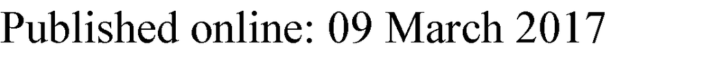

1.<sup>References</sup>

Oldershaw RA. Cell sources for the regeneration of articular cartilage: the

past, the horizon and the future. Int J Exp Pathol. 2012;93(6):389–400.

doi:10.1111/j.1365-2613.2012.00837.x.

2.

Dozin B, Malpeli M, Cancedda R, et al. Comparative evaluation of

autologous chondrocyte implantation and mosaicplasty: a multicentered

randomized clinical trial. Clin J Sport Med. 2005;15(4):220–6. Available at:

https://www.ncbi.nlm.nih.gov/pubmed/16003035. Accessed 12 June 2016.

3.

Levy AS, Lohnes J, Sculley S, LeCroy M, Garrett W. Chondral delamination of

the knee in soccer players. Am J Sports Med. 1996;24(5):634–9. Available at:

http://www.ncbi.nlm.nih.gov/pubmed/8883684. Accessed 12 June 2016.

4.

Badri A, Burkhardt J. Arthroscopic debridement of unicompartmental

arthritis: fact or fiction? Clin Sports Med. 2014;33(1):23–41. doi:10.1016/j.

csm.2013.08.008.

5.

Moseley JB, O’Malley K, Petersen NJ, et al. A controlled trial of arthroscopic

surgery for osteoarthritis of the knee. N Engl J Med. 2002;347(2):81–8.

doi:10.1056/NEJMoa013259.

6.

Bedi A, Feeley BT, Williams RJ. Management of articular cartilage

defects of the knee. J Bone Joint Surg Am. 2010;92(4):994–1009.

doi:10.2106/JBJS.I.00895.

7.

Steinwachs MR, Guggi T, Kreuz PC. Marrow stimulation techniques. Injury.

2008;39 Suppl 1:S26–31. doi:10.1016/j.injury.2008.01.042.

8.

Steadman JR, Briggs KK, Rodrigo JJ, Kocher MS, Gill TJ, Rodkey WG.

Outcomes of microfracture for traumatic chondral defects of the knee:

average 11-year follow-up. Arthroscopy. 19(5):477-84. doi:10.1053/jars.

2003.50112.

9.

Peterson L, Menche D, Grande D PM. Chondrocyte transplantation: an

experimental model in the rabbit. Trans Orthop Res Soc. 1984;9:218.

10.

Brittberg M, Lindahl A, Nilsson A, Ohlsson C, Isaksson O, Peterson L.

Treatment of deep cartilage defects in the knee with autologous

chondrocyte transplantation. N Engl J Med. 1994;331(14):889–95.

doi:10.1056/NEJM199410063311401.

11.

Jones DG, Peterson L. Autologous chondrocyte implantation. J Bone Joint

Surg Am. 2006;88(11):2502–20. Available at: http://www.ncbi.nlm.nih.gov/

pubmed/17115530. Accessed 12 June 2016.

12.

Minas T. Autologous chondrocyte implantation in the arthritic knee.

Orthopedics. 2003;26(9):945–7. Available at: http://www.ncbi.nlm.nih.gov/

pubmed/14503759. Accessed 12 June 2016.

13.

Brittberg M. Cell carriers as the next generation of cell therapy for

cartilage repair: a review of the matrix-induced autologous chondrocyte

implantation procedure. Am J Sports Med. 2010;38(6):1259–71. doi:10.1177/

0363546509346395.

14.

Matsusue Y, Yamamuro T, Hama H. Arthroscopic multiple osteochondral

transplantation to the chondral defect in the knee associated with anterior

cruciate ligament disruption. Arthroscopy. 1993;9(3):318–21. Available at:

http://www.ncbi.nlm.nih.gov/pubmed/8323618. Accessed 12 June 2016.

15.

Bentley G, Biant LC, Vijayan S, Macmull S, Skinner JA, Carrington RWJ.

Minimum ten-year results of a prospective randomised study of autologous

chondrocyte implantation versus mosaicplasty for symptomatic articular

cartilage lesions of the knee. J Bone Joint Surg Br. 2012;94(4):504–9.

doi:10.1302/0301-620X.94B4.27495.

16.

De Caro F, Bisicchia S, Amendola A, Ding L. Large fresh osteochondral

allografts of the knee: a systematic clinical and basic science review of the

literature. Arthroscopy. 2015;31(4):757–65. doi:10.1016/j.arthro.2014.11.025.

17.

Capeci CM, Turchiano M, Strauss EJ, Youm T. Osteochondral allografts:

applications in treating articular cartilage defects in the knee. Bull Hosp Jt Dis.

2013;71(1):60–7. Available at: http://www.ncbi.nlm.nih.gov/pubmed/24032585.

Accessed 12 June 2016.

18.

Bugbee WD, Khanna G, Cavallo M, McCauley JC, Görtz S, Brage ME.

Bipolar fresh osteochondral allografting of the tibiotalar joint. J Bone

Joint Surg Am. 2013;95(5):426–32. doi:10.2106/JBJS.L.00165.

19.

Gossec L, Paternotte S, Maillefert JF, et al. The role of pain and functional

impairment in the decision to recommend total joint replacement in hip

and knee osteoarthritis: an international cross-sectional study of 1909

patients. Report of the OARSI-OMERACT Task Force on total joint

replacement. Osteoarthritis Cartilage. 2011;19(2):147–54. doi:10.1016/

j.joca.2010.10.025.

20.

Shapiro F, Koide S, Glimcher MJ. Cell origin and differentiation in the repair

of full-thickness defects of articular cartilage. J Bone Joint Surg Am. 1993;

75(4):532–53. Available at: http://www.ncbi.nlm.nih.gov/pubmed/8478382.

Accessed 12 June 2016.

21.

Mithoefer K, Williams RJ, Warren RF, Wickiewicz TL, Marx RG. High-impact

athletics after knee articular cartilage repair: a prospective evaluation of the

microfracture technique. Am J Sports Med. 2006;34(9):1413–8. doi:10.1177/

0363546506288240.

22.

Gobbi A, Nunag P, Malinowski K. Treatment of full thickness chondral

lesions of the knee with microfracture in a group of athletes. Knee Surg

Sports Traumatol Arthrosc. 2005;13(3):213–21. doi:10.1007/s00167-004-0499-3.

23.

Frisbie DD, Trotter GW, Powers BE, et al. Arthroscopic subchondral bone

plate microfracture technique augments healing of large chondral defects

in the radial carpal bone and medial femoral condyle of horses. Vet Surg.

28(4):242-55. Available at: http://www.ncbi.nlm.nih.gov/pubmed/10424704.

Accessed 12 June 2016.

24.

Bae DK, Yoon KH, Song SJ. Cartilage healing after microfracture in

osteoarthritic knees. Arthroscopy. 2006;22(4):367–74. doi:10.1016/j.arthro.

2006.01.015.

25.

Brown WE, Potter HG, Marx RG, Wickiewicz TL, Warren RF. Magnetic

resonance imaging appearance of cartilage repair in the knee. Clin Orthop

Relat Res. 2004;(422):214-23. Available at: http://www.ncbi.nlm.nih.gov/

pubmed/15187860. Accessed 12 June 2016.

26.

Minas T, Gomoll AH, Rosenberger R, Royce RO, Bryant T. Increased failure

rate of autologous chondrocyte implantation after previous treatment with

marrow stimulation techniques. Am J Sports Med. 2009;37(5):902–8.

doi:10.1177/0363546508330137.

27.

Bartha L, Vajda A, Duska Z, Rahmeh H, Hangody L. Autologous osteochondral

mosaicplasty grafting. J Orthop Sports Phys Ther. 2006;36(10):739–50.

doi:10.2519/jospt.2006.2182.

28.

Feczkó P, Hangody L, Varga J, et al. Experimental results of donor site filling

for autologous osteochondral mosaicplasty. Arthroscopy. 2003;19(7):755–61.

Available at: http://www.ncbi.nlm.nih.gov/pubmed/12966384. Accessed

12 June 2016.

29.

Bentley G, Bhamra JS, Gikas PD, Skinner JA, Carrington R, Briggs TW.

Repair of osteochondral defects in joints—how to achieve success.

Injury. 2013;44 Suppl 1:S3–10. doi:10.1016/S0020-1383(13)70003-2.

30.

Wood JJ, Malek MA, Frassica FJ, et al. Autologous cultured chondrocytes:

adverse events reported to the United States Food and Drug

Administration. J Bone Joint Surg Am. 2006;88(3):503–7. doi:10.2106/

JBJS.E.00103.

31.

Peterson L, Minas T, Brittberg M, Nilsson A, Sjögren-Jansson E, Lindahl A.

Two- to 9-year outcome after autologous chondrocyte transplantation

of the knee. Clin Orthop Relat Res. 2000;(374):212-34. Available at:

http://www.ncbi.nlm.nih.gov/pubmed/10818982. Accessed 12 June 2016.

32.

Benya PD, Shaffer JD. Dedifferentiated chondrocytes reexpress the

differentiated collagen phenotype when cultured in agarose gels.

Cell. 1982;30(1):215–24. Available at: http://www.ncbi.nlm.nih.gov/pubmed/

7127471. Accessed 12 June 2016.

33.

Takata N, Furumatsu T, Abe N, Naruse K, Ozaki T. Comparison between

loose fragment chondrocytes and condyle fibrochondrocytes in cellular

proliferation and redifferentiation. J Orthop Sci. 2011;16(5):589–97. doi:10.1007/

s00776-011-0128-1.

34.

Keramaris NC, Kanakaris NK, Tzioupis C, Kontakis G, Giannoudis PV.

Translational research: from benchside to bedside. Injury. 2008;39(6):643–50.

doi:10.1016/j.injury.2008.01.051.

35.

Woolf SH. The meaning of translational research and why it matters.

JAMA. 2008;299(2):211–3. doi:10.1001/jama.2007.26.

36.

Bartlett W, Skinner JA, Gooding CR, et al. Autologous chondrocyte

implantation versus matrix-induced autologous chondrocyte implantation

for osteochondral defects of the knee: a prospective, randomised study.

J Bone Joint Surg Br. 2005;87(5):640–5. doi:10.1302/0301-620X.87B5.15905.

37.

Bhosale AM, Richardson JB. Articular cartilage: structure, injuries and review

of management. Br Med Bull. 2008;87:77–95. doi:10.1093/bmb/ldn025.

38.

Koga H, Engebretsen L, Brinchmann JE, Muneta T, Sekiya I. Mesenchymal

stem cell-based therapy for cartilage repair: a review. Knee Surg Sports

Traumatol Arthrosc. 2009;17(11):1289–97. doi:10.1007/s00167-009-0782-4.

39.

Kon E, Verdonk P, Condello V, et al. Matrix-assisted autologous chondrocyte

transplantation for the repair of cartilage defects of the knee: systematic

clinical data review and study quality analysis. Am J Sports Med. 2009;37

Suppl 1:156S–66S. doi:10.1177/0363546509351649.

40.

Lubis AM, Lubis VK. Adult bone marrow stem cells in cartilage therapy.

Acta Med Indones. 2012;44(1):62–8. Available at: http://www.ncbi.nlm.nih.gov/

pubmed/22451188. Accessed 12 June 2016.

41.

Magnussen RA, Dunn WR, Carey JL, Spindler KP. Treatment of focal articular

cartilage defects in the knee: a systematic review. Clin Orthop Relat Res.

2008;466(4):952–62. doi:10.1007/s11999-007-0097-z.

42.

Matsumoto T, Okabe T, Ikawa T, et al. Articular cartilage repair with autologous

bone marrow mesenchymal cells. J Cell Physiol. 2010;225(2):291–5.

doi:10.1002/jcp.22223.

43.

Maumus M, Guérit D, Toupet K, Jorgensen C, Noël D. Mesenchymal stem

cell-based therapies in regenerative medicine: applications in rheumatology.

Stem Cell Res Ther. 2011;2(2):14. doi:10.1186/scrt55.

44.

Pastides P, Chimutengwende-Gordon M, Maffulli N, Khan W. Stem cell

therapy for human cartilage defects: a systematic review. Osteoarthritis

Cartilage. 2013;21(5):646–54. doi:10.1016/j.joca.2013.02.008.

45.

Ye K, Di Bella C, Myers DE, Choong PFM. The osteochondral dilemma: review

of current management and future trends. ANZ J Surg. 2014;84(4):211–7.

doi:10.1111/ans.12108.

46.

Zengerink M, Struijs PAA, Tol JL, van Dijk CN. Treatment of osteochondral

lesions of the talus: a systematic review. Knee Surg Sports Traumatol

Arthrosc. 2010;18(2):238–46. doi:10.1007/s00167-009-0942-6.

47.

Liberati A, Altman DG, Tetzlaff J, et al. PRISMA statement for reporting

systematic reviews and meta-analyses of studies that evaluate healthcare

interventions: explanation and elaboration. BMJ. 2009;339:b2700. Available

at: http://www.ncbi.nlm.nih.gov/pubmed/19622552. Accessed 12 June 2016.

48.

Zhang B, Yang S, Sun Z, et al. Human mesenchymal stem cells induced by

growth differentiation factor 5: an improved self-assembly tissue

engineering method for cartilage repair. Tissue Eng Part C Methods.

2011;17(12):1189–99. doi:10.1089/ten.tec.2011.0011.

49.

Nam HY, Karunanithi P, Loo WC, et al. The effects of staged intra-articular

injection of cultured autologous mesenchymal stromal cells on the repair

of damaged cartilage: a pilot study in caprine model. Arthritis Res Ther.

2013;15(5):R129. doi:10.1186/ar4309.

50.

Li Z, Kupcsik L, Yao S-J, Alini M, Stoddart MJ. Chondrogenesis of human

bone marrow mesenchymal stem cells in fibrin-polyurethane composites.

Tissue Eng Part A. 2009;15(7):1729–37. doi:10.1089/ten.tea.2008.0247.

51.

Erickson IE, Kestle SR, Zellars KH, Dodge GR, Burdick JA, Mauck RL. Improved

cartilage repair via in vitro pre-maturation of MSC-seeded hyaluronic acid

hydrogels. Biomed Mater. 2012;7(2):24110. doi:10.1088/1748-6041/7/2/024110.

52.

Hui TY, Cheung KMC, Cheung WL, Chan D, Chan BP. In vitro chondrogenic

differentiation of human mesenchymal stem cells in collagen microspheres:

influence of cell seeding density and collagen concentration. Biomaterials.

2008;29(22):3201–12. doi:10.1016/j.biomaterials.2008.04.001.

53.

Huang C-YC, Reuben PM, D’Ippolito G, Schiller PC, Cheung HS.

Chondrogenesis of human bone marrow-derived mesenchymal stem cells

in agarose culture. Anat Rec A Discov Mol Cell Evol Biol. 2004;278(1):428–36.

doi:10.1002/ar.a.20010.

54.

Wang ZJ, An RZ, Zhao JY, et al. Repair of articular cartilage defects by tissue-

engineered cartilage constructed with adipose-derived stem cells and

acellular cartilaginous matrix in rabbits. Genet Mol Res. 2014;13(2):4599–606.

doi:10.4238/2014.June.18.2.

55.

Raheja LF, Galuppo LD, Bowers-Lepore J, Dowd JP, Tablin F, Yellowley CE.

Treatment of bilateral medial femoral condyle articular cartilage fissures in a

horse using bone marrow-derived multipotent mesenchymal stromal cells.

J Equine Vet Sci. 2011;31(3):147–54. doi:10.1016/j.jevs.2010.12.009.

56.

Wu G, Cui Y, Wang Y, et al. Repair of cartilage defects in BMSCs via CDMP1

gene transfection. Genet Mol Res Mol Res. 2014;13(131):291–301. doi:10.4238/

2014.January.17.14.

57.

Mokbel AN, El Tookhy OS, Shamaa AA, Rashed LA, Sabry D, El Sayed AM.

Homing and reparative effect of intra-articular injection of autologus

mesenchymal stem cells in osteoarthritic animal model. BMC Musculoskelet

Disord. 2011;12:259. doi:10.1186/1471-2474-12-259.

58.

Masuoka K, Asazuma T, Hattori H, et al. Tissue engineering of articular

cartilage with autologous cultured adipose tissue-derived stromal cells

using atelocollagen honeycomb-shaped scaffold with a membrane sealing

in rabbits. J Biomed Mater Res B Appl Biomater. 2006;79(1):25–34. doi:10.

1002/jbm.b.30507.

59.

Zhang K, Zhang Y, Yan S, et al. Repair of an articular cartilage defect using

adipose-derived stem cells loaded on a polyelectrolyte complex scaffold

based on poly(l-glutamic acid) and chitosan. Acta Biomater. 2013;9(7):7276–88.

doi:10.1016/j.actbio.2013.03.025.

60.

Zhu S, Chen P, Wu Y, et al. Programmed application of transforming growth

factor β3 and Rac1 inhibitor NSC23766 committed hyaline cartilage

differentiation of adipose-derived stem cells for osteochondral defect repair.

Stem Cells Transl Med. 2014;3(10):1242–51. doi:10.5966/sctm.2014-0042.

61.

Murata D, Tokunaga S, Tamura T, et al. A preliminary study of osteochondral

regeneration using a scaffold-free three-dimensional construct of porcine

adipose tissue-derived mesenchymal stem cells. J Orthop Surg Res. 2015;10:35.

doi:10.1186/s13018-015-0173-0.

62.

Cui L, Wu Y, Cen L, et al. Repair of articular cartilage defect in non-weight

bearing areas using adipose derived stem cells loaded polyglycolic acid mesh.

Biomaterials. 2009;30(14):2683–93. doi:10.1016/j.biomaterials.2009.01.045.

63.

Lu C-H, Yeh T-S, Yeh C-L, et al. Regenerating cartilages by Engineered

ASCs: prolonged TGF-β3/BMP-6 expression improved articular cartilage

formation and restored zonal structure. Mol Ther. 2014;22(1):186–95.

doi:10.1038/mt.2013.165.

64.

Dragoo JL, Carlson G, McCormick F, et al. Healing full-thickness cartilage

defects using adipose-derived stem cells. Tissue Eng. 2007;13(7):1615–21.

doi:10.1089/ten.2006.0249.

65.

Portron S, Merceron C, Gauthier O, et al. Effects of in vitro low oxygen

tension preconditioning of adipose stromal cells on their in vivo

chondrogenic potential: application in cartilage tissue repair. PLoS One.

2013;8(4):e62368. doi:10.1371/journal.pone.0062368. Abhay Pandit, ed.

66.

Im G-I, Lee JH. Repair of osteochondral defects with adipose stem cells and

a dual growth factor-releasing scaffold in rabbits. J Biomed Mater Res B

Appl Biomater. 2010;92(2):552–60. doi:10.1002/jbm.b.31552.

67.

Kang H, Peng J, Lu S, et al. In vivo cartilage repair using adipose-derived

stem cell-loaded decellularized cartilage ECM scaffolds. J Tissue Eng Regen

Med. 2014;8(6):442–53. doi:10.1002/term.1538.

68.

Gong L, Zhou X, Wu Y, et al. Proteomic analysis profile of engineered

articular cartilage with chondrogenic differentiated adipose tissue-

derived stem cells loaded polyglycolic acid mesh for weight-bearing

area defect repair. Tissue Eng Part A. 2014;20(3-4):575–87. doi:10.1089/

ten.TEA.2013.0205.

69.

de Girolamo L, Niada S, Arrigoni E, et al. Repair of osteochondral defects in

the minipig model by OPF hydrogel loaded with adipose-derived

mesenchymal stem cells. Regen Med. 2015;10(2):135–51. doi:10.2217/rme.14.77.

70.

Pei M, He F, Li J, Tidwell JE, Jones AC, McDonough EB. Repair of large

animal partial-thickness cartilage defects through intraarticular injection of

matrix-rejuvenated synovium-derived stem cells. Tissue Eng Part A.

2013;19(9-10):1144–54. doi:10.1089/ten.TEA.2012.0351.

71.

Lee J-C, Lee SY, Min HJ, et al. Synovium-derived mesenchymal stem cells

encapsulated in a novel injectable gel can repair osteochondral defects in a

rabbit model. Tissue Eng Part A. 2012;18(19-20):2173–86. doi:10.1089/ten.

TEA.2011.0643.

72.

Nakamura T, Sekiya I, Muneta T, et al. Arthroscopic, histological and MRI

analyses of cartilage repair after a minimally invasive method of

transplantation of allogeneic synovial mesenchymal stromal cells into

cartilage defects in pigs. Cytotherapy. 2012;14(3):327–38. doi:10.3109/

14653249.2011.638912.

73.

Koga H, Shimaya M, Muneta T, et al. Local adherent technique for

transplanting mesenchymal stem cells as a potential treatment of cartilage

defect. Arthritis Res Ther. 2008;10(4):R84. doi:10.1186/ar2460.

74.

Lee J-C, Min HJ, Lee S, Seong SC, Lee MC. Effect of chondroitinase ABC

on adhesion and behavior of synovial membrane-derived mesenchymal

stem cells in rabbit partial-thickness chondral defects. J Orthop Res.

2013;31(8):1293–301. doi:10.1002/jor.22353.

75.

Lee J-C, Min HJ, Park HJ, Lee S, Seong SC, Lee MC. Synovial membrane-

derived mesenchymal stem cells supported by platelet-rich plasma can repair

osteochondral defects in a rabbit model. Arthroscopy. 2013;29(6):1034–46.

doi:10.1016/j.arthro.2013.02.026.

76.

Perka C, Schultz O, Spitzer R-S, Lindenhayn K. The influence of transforming

growth factor β1 on mesenchymal cell repair of full-thickness cartilage

defects. J Biomed Mater Res. 2000;52(3):543–52. doi:10.1002/1097-

4636(20001205)52:3<543::AID-JBM13>3.0.CO;2-2.

77.

Hui JHP, Chen F, Thambyah A, Lee EH. Treatment of chondral lesions in

advanced osteochondritis dissecans: a comparative study of the efficacy of

chondrocytes, mesenchymal stem cells, periosteal graft, and mosaicplasty

(osteochondral autograft) in animal models. J Pediatr Orthop. 24(4):427-33.

Available at: http://www.ncbi.nlm.nih.gov/pubmed/15205626. Accessed

12 June 2016.

78.

Gelse K, von der Mark K, Aigner T, Park J, Schneider H. Articular cartilage

repair by gene therapy using growth factor-producing mesenchymal cells.

Arthritis Rheum. 2003;48(2):430–41. doi:10.1002/art.10759.

79.

Zhang S, Jiang YZ, Zhang W, et al. Neonatal desensitization supports

long-term survival and functional integration of human embryonic stem

cell-derived mesenchymal stem cells in rat joint cartilage without

immunosuppression. Stem Cells Dev. 2013;22(1):90–101. doi:10.1089/

scd.2012.0116.

80.

Wakitani S, Aoki H, Harada Y, et al. Embryonic stem cells form articular

cartilage, not teratomas, in osteochondral defects of rat joints. Cell

Transplant. 2004;13(4):331–6. Available at: http://www.ncbi.nlm.nih.gov/

pubmed/15468674. Accessed 12 June 2016.

81.

Chung J, Song M, Ha C-W, Kim J-A, Lee C-H, Park Y-B. Comparison of

articular cartilage repair with different hydrogel-human umbilical cord

blood-derived mesenchymal stem cell composites in a rat model. Stem Cell

Res Ther. 2014;5(2):39. doi:10.1186/scrt427.

82.

Nawata M, Wakitani S, Nakaya H, et al. Use of bone morphogenetic protein

2 and diffusion chambers to engineer cartilage tissue for the repair of

defects in articular cartilage. Arthritis Rheum. 2005;52(1):155–63. doi:10.

1002/art.20713.

83.

Grande DA, Southerland SS, Manji R, Pate DW, Schwartz RE, Lucas PA. Repair

of articular cartilage defects using mesenchymal stem cells. Tissue Eng.

1995;1(4):345–53. doi:10.1089/ten.1995.1.345.

84.

Tay LX, Ahmad RE, Dashtdar H, et al. Treatment outcomes of alginate-

embedded allogenic mesenchymal stem cells versus autologous

chondrocytes for the repair of focal articular cartilage defects in a

rabbit model. Am J Sports Med. 2012;40(1):83–90. doi:10.1177/

0363546511420819.

85.

Dashtdar H, Rothan HA, Tay T, et al. A preliminary study comparing the use

of allogenic chondrogenic pre-differentiated and undifferentiated

mesenchymal stem cells for the repair of full thickness articular cartilage

defects in rabbits. J Orthop Res. 2011;29(9):1336–42. doi:10.1002/jor.21413.

86.

Igarashi T, Iwasaki N, Kawamura D, et al. Repair of articular cartilage defects

with a novel injectable in situ forming material in a canine model. J Biomed

Mater Res A. 2012;100(1):180–7. doi:10.1002/jbm.a.33248.

87.

Ho STB, Hutmacher DW, Ekaputra AK, Hitendra D, Hui JH. The evaluation of

a biphasic osteochondral implant coupled with an electrospun membrane

in a large animal model. Tissue Eng Part A. 2010;16(4):1123–41. doi:10.1089/

ten.TEA.2009.0471.

88.

Oshima Y, Harwood FL, Coutts RD, Kubo T, Amiel D. Variation of

mesenchymal cells in polylactic acid scaffold in an osteochondral repair

model. Tissue Eng Part C Methods. 2009;15(4):595–604. doi:10.1089/

ten.TEC.2008.0487.

89.

Al Faqeh H, Nor Hamdan BMY, Chen HC, Aminuddin BS, Ruszymah BHI. The

potential of intra-articular injection of chondrogenic-induced bone marrow

stem cells to retard the progression of osteoarthritis in a sheep model. Exp

Gerontol. 2012;47(6):458–64. doi:10.1016/j.exger.2012.03.018.

90.

Iwai R, Fujiwara M, Wakitani S, Takagi M. Ex vivo cartilage defect model for

the evaluation of cartilage regeneration using mesenchymal stem cells.

J Biosci Bioeng. 2011;111(3):357–64. doi:10.1016/j.jbiosc.2010.11.001.

91.

Nishimori M, Deie M, Kanaya A, Exham H, Adachi N, Ochi M. Repair of

chronic osteochondral defects in the rat. A bone marrow-stimulating

procedure enhanced by cultured allogenic bone marrow mesenchymal

stromal cells. J Bone Joint Surg Br. 2006;88(9):1236–44. doi:10.1302/

0301-620X.88B9.17810.

92.

Espinosa M, Vaisman A, Nazal N, Figueroa D, Gallegos M, Conget P.

Intraarticular administration of dexamethasone after mesenchymal stem

cells implantation does not improve significantly the treatment of

preestablished full-thickness chondral defect in a rabbit model. Cartilage.

2013;4(2):144–52. doi:10.1177/1947603512472696.

93.

Deng T, Lv J, Pang J, Liu B, Ke J. Construction of tissue-engineered

osteochondral composites and repair of large joint defects in rabbit.

J Tissue Eng Regen Med. 2014;8(7):546–56. doi:10.1002/term.1556.

94.

Wan W, Li Q, Gao H, et al. BMSCs laden injectable amino-diethoxypropane

modified alginate-chitosan hydrogel for hyaline cartilage reconstruction.

J Mater Chem B. 2015;3(9):1990–2005. doi:10.1039/C4TB01394H.

95.

Saw K-Y, Hussin P, Loke S-C, et al. Articular cartilage regeneration with

autologous marrow aspirate and hyaluronic acid: an experimental study

in a goat model. Arthroscopy. 2009;25(12):1391–400. doi:10.1016/j.arthro.

2009.07.011.

96.

McIlwraith CW, Frisbie DD, Rodkey WG, et al. Evaluation of intra-articular

mesenchymal stem cells to augment healing of microfractured chondral

defects. Arthroscopy. 2011;27(11):1552–61. doi:10.1016/j.arthro.2011.06.002.

97.

Mokbel A, El-Tookhy O, Shamaa AA, Sabry D, Rashed L, Mostafa A. Homing

and efficacy of intra-articular injection of autologous mesenchymal stem

cells in experimental chondral defects in dogs. Clin Exp Rheumatol. 29(2):

275-84. Available at: http://www.ncbi.nlm.nih.gov/pubmed/21385540.

Accessed 12 June 2016.

98.

Fortier LA, Potter HG, Rickey EJ, et al. Concentrated bone marrow aspirate

improves full-thickness cartilage repair compared with microfracture in the

equine model. J Bone Joint Surg Am. 2010;92(10):1927–37. doi:10.2106/JBJS.

I.01284.

99.

Zhao Q, Wang S, Tian J, et al. Combination of bone marrow concentrate

and PGA scaffolds enhance bone marrow stimulation in rabbit articular

cartilage repair. J Mater Sci Mater Med. 2013;24(3):793–801. doi:10.1007/

s10856-012-4841-x.

100. Sun J, Hou X-K, Li X, et al. Mosaicplasty associated with gene enhanced

tissue engineering for the treatment of acute osteochondral defects in a

goat model. Arch Orthop Trauma Surg. 2009;129(6):757–71. doi:10.1007/

s00402-008-0761-0.

101. Leng P, Ding C, Zhang H, Wang Y. Reconstruct large osteochondral defects

of the knee with hIGF-1 gene enhanced Mosaicplasty. Knee. 2012;19(6):804–11.

doi:10.1016/j.knee.2012.03.009.

102. Ma X, Sun Y, Cheng X, et al. Repair of osteochondral defects by

mosaicplasty and allogeneic BMSCs transplantation. Int J Clin Exp Med.

2015;8(4):6053–9. Available at: http://www.ncbi.nlm.nih.gov/pubmed/

26131203. Accessed 12 June 2016.

103. Vega A, Martín-Ferrero MA, Del Canto F, et al. Treatment of knee

osteoarthritis with allogeneic bone marrow mesenchymal stem cells: a

randomized controlled trial. Transplantation. 2015;99(8):1681–90. doi:10.1097/

TP.0000000000000678.

104. Centeno CJ, Busse D, Kisiday J, Keohan C, Freeman M, Karli D. Increased

knee cartilage volume in degenerative joint disease using percutaneously

implanted, autologous mesenchymal stem cells. Pain Physician. 11(3):343-53.

Available at: http://www.ncbi.nlm.nih.gov/pubmed/18523506. Accessed

13 June 2016.

105. Davatchi F, Abdollahi BS, Mohyeddin M, Shahram F, Nikbin B. Mesenchymal

stem cell therapy for knee osteoarthritis. Preliminary report of four patients.

Int J Rheum Dis. 2011;14(2):211–5. doi:10.1111/j.1756-185X.2011.01599.x.

106. Pak J. Regeneration of human bones in hip osteonecrosis and human

cartilage in knee osteoarthritis with autologous adipose-tissue-derived stem

cells: a case series. J Med Case Rep. 2011;5:296. doi:10.1186/1752-1947-5-296.

107. Koh YG, Choi YJ, Kwon OR, Kim YS. Second-look arthroscopic evaluation

of cartilage lesions after mesenchymal stem cell implantation in

osteoarthritic knees. Am J Sports Med. 2014;42(7):1628–37. doi:10.1177/

0363546514529641.

108. Kim YS, Choi YJ, Suh DS, et al. Mesenchymal stem cell implantation in

osteoarthritic knees: is fibrin glue effective as a scaffold? Am J Sports Med.

2015;43(1):176–85. doi:10.1177/0363546514554190.

109. Emadedin M, Aghdami N, Taghiyar L, et al. Intra-articular injection of

autologous mesenchymal stem cells in six patients with knee osteoarthritis.

Arch Iran Med. 2012;15(7):422-8. doi:012157/AIM.0010.

110. Jo CH, Lee YG, Shin WH, et al. Intra-articular injection of mesenchymal stem

cells for the treatment of osteoarthritis of the knee: a proof-of-concept

clinical trial. Stem Cells. 2014;32(5):1254–66. doi:10.1002/stem.1634.

111. Orozco L, Munar A, Soler R, et al. Treatment of knee osteoarthritis with

autologous mesenchymal stem cells: a pilot study. Transplantation.

2013;95(12):1535–41. doi:10.1097/TP.0b013e318291a2da.

112. Emadedin M, Ghorbani Liastani M, Fazeli R, et al. Long-term follow-up of

intra-articular injection of autologous mesenchymal stem cells in patients

with knee, ankle, or hip osteoarthritis. Arch Iran Med. 2015;18(6):336-44.

doi:015186/AIM.003.

113. Wakitani S, Imoto K, Yamamoto T, Saito M, Murata N, Yoneda M. Human

autologous culture expanded bone marrow mesenchymal cell

transplantation for repair of cartilage defects in osteoarthritic knees.

Osteoarthritis Cartilage. 2002;10(3):199–206. doi:10.1053/joca.2001.0504.

114. Koh Y-G, Choi Y-J. Infrapatellar fat pad-derived mesenchymal stem cell

therapy for knee osteoarthritis. Knee. 2012;19(6):902–7. doi:10.1016/j.knee.

2012.04.001.

115. Wong KL, Lee KBL, Tai BC, Law P, Lee EH, Hui JHP. Injectable cultured

bone marrow-derived mesenchymal stem cells in varus knees with

cartilage defects undergoing high tibial osteotomy: a prospective,

randomized controlled clinical trial with 2 years’ follow-up. Arthroscopy.

2013;29(12):2020–8. doi:10.1016/j.arthro.2013.09.074.

116. Giannini S, Buda R, Vannini F, Cavallo M, Grigolo B. One-step bone marrow-

derived cell transplantation in talar osteochondral lesions. Clin Orthop Relat

Res. 2009;467(12):3307–20. doi:10.1007/s11999-009-0885-8.

117. Giannini S, Buda R, Cavallo M, et al. Cartilage repair evolution in post-

traumatic osteochondral lesions of the talus: from open field autologous

chondrocyte to bone-marrow-derived cells transplantation. Injury.

2010;41(11):1196–203. doi:10.1016/j.injury.2010.09.028.

118. Wakitani S, Mitsuoka T, Nakamura N, Toritsuka Y, Nakamura Y, Horibe S.

Autologous bone marrow stromal cell transplantation for repair of full-

thickness articular cartilage defects in human patellae: two case reports. Cell

Transplant. 2004;13(5):595–600. Available at: http://www.ncbi.nlm.nih.gov/

pubmed/15565871. Accessed 13 June 2016.

119. Saw K-Y, Anz A, Merican S, et al. Articular cartilage regeneration with

autologous peripheral blood progenitor cells and hyaluronic acid after

arthroscopic subchondral drilling: a report of 5 cases with histology.

Arthroscopy. 2011;27(4):493–506. doi:10.1016/j.arthro.2010.11.054.

120. Nejadnik H, Hui JH, Feng Choong EP, Tai B-C, Lee EH. Autologous bone

marrow-derived mesenchymal stem cells versus autologous chondrocyte

implantation: an observational cohort study. Am J Sports Med.

2010;38(6):1110–6. doi:10.1177/0363546509359067.

121. Saw K-Y, Anz A, Siew-Yoke Jee C, et al. Articular cartilage regeneration with

autologous peripheral blood stem cells versus hyaluronic acid: a

randomized controlled trial. Arthroscopy. 2013;29(4):684–94. doi:10.1016/j.

arthro.2012.12.008.

122. Wakitani S, Nawata M, Tensho K, Okabe T, Machida H, Ohgushi H. Repair of

articular cartilage defects in the patello-femoral joint with autologous bone

marrow mesenchymal cell transplantation: three case reports involving nine

defects in five knees. J Tissue Eng Regen Med. 1(1):74-9. doi:10.1002/term.8.

123. Lee KBL, Wang VTZ, Chan YH, Hui JHP. A novel, minimally-invasive

technique of cartilage repair in the human knee using arthroscopic

microfracture and injections of mesenchymal stem cells and hyaluronic

acid—a prospective comparative study on safety and short-term efficacy.

Ann Acad Med Singapore. 2012;41(11):511–7. Available at: http://www.ncbi.

nlm.nih.gov/pubmed/23235728. Accessed 16 June 2016.

124. Kuroda R, Ishida K, Matsumoto T, et al. Treatment of a full-thickness articular

cartilage defect in the femoral condyle of an athlete with autologous bone-

marrow stromal cells. Osteoarthritis Cartilage. 2007;15(2):226–31. doi:10.

1016/j.joca.2006.08.008.

125. Haleem AM, El Singergy AA, Sabry D, et al. The clinical use of human

culture-expanded autologous bone marrow mesenchymal stem cells

transplanted on platelet-rich fibrin glue in the treatment of articular

cartilage defects: a pilot study and preliminary results. Cartilage.

2010;1(4):253–61. doi:10.1177/1947603510366027.

126. Kasemkijwattana C, Hongeng S, Kesprayura S, Rungsinaporn V, Chaipinyo K,

Chansiri K. Autologous bone marrow mesenchymal stem cells implantation

for cartilage defects: two cases report. J Med Assoc Thai. 2011;94(3):395–400.

Available at: http://www.ncbi.nlm.nih.gov/pubmed/21560849. Accessed 13

June 2016.

127. Gigante A, Cecconi S, Calcagno S, Busilacchi A, Enea D. Arthroscopic knee

cartilage repair with covered microfracture and bone marrow concentrate.

Arthrosc Tech. 2012;1(2):e175–80. doi:10.1016/j.eats.2012.07.001.

128. Shetty AA, Kim SJ, Shetty V, et al. Autologous bone-marrow mesenchymal

cell induced chondrogenesis: single-stage arthroscopic cartilage repair.

Tissue Eng Regen Med. 2014;11(3):247–53. doi:10.1007/s13770-014-0061-4.

129. Akgun I, Unlu MC, Erdal OA, et al. Matrix-induced autologous mesenchymal

stem cell implantation versus matrix-induced autologous chondrocyte

implantation in the treatment of chondral defects of the knee: a 2-year

randomized study. Arch Orthop Trauma Surg. 2015;135(2):251–63. doi:10.

1007/s00402-014-2136-z.

130. Buda R, Vannini F, Cavallo M, Grigolo B, Cenacchi A, Giannini S.

Osteochondral lesions of the knee: a new one-step repair technique with

bone-marrow-derived cells. J Bone Joint Surg Am. 2010;92 Suppl 2:2–11.

doi:10.2106/JBJS.J.00813.

131. Enea D, Cecconi S, Calcagno S, et al. Single-stage cartilage repair in the

knee with microfracture covered with a resorbable polymer-based matrix

and autologous bone marrow concentrate. Knee. 2013;20(6):562–9.

doi:10.1016/j.knee.2013.04.003.

132. Gobbi A, Chaurasia S, Karnatzikos G, Nakamura N. Matrix-induced

autologous chondrocyte implantation versus multipotent stem cells for the

treatment of large patellofemoral chondral lesions: a nonrandomized

prospective trial. Cartilage. 2015;6(2):82–97. doi:10.1177/1947603514563597.

133. Sekiya I, Muneta T, Horie M, Koga H. Arthroscopic transplantation of synovial

stem cells improves clinical outcomes in knees with cartilage defects. Clin

Orthop Relat Res. 2015;473(7):2316–26. doi:10.1007/s11999-015-4324-8.

134. Katayama R, Wakitani S, Tsumaki N, et al. Repair of articular cartilage defects

in rabbits using CDMP1 gene-transfected autologous mesenchymal cells

derived from bone marrow. Rheumatology (Oxford). 2004;43(8):980–5.

doi:10.1093/rheumatology/keh240.

135. Insall JN. Intra-articular surgery for degenerative arthritis of the knee. A report

of the work of the late K. H. Pridie. J Bone Joint Surg Br. 1967;49(2):211–28.

Available at: http://www.ncbi.nlm.nih.gov/pubmed/6026508. Accessed

8 July 2016.

136. Meachim G, Roberts C. Repair of the joint surface from subarticular tissue in

the rabbit knee. J Anat. 1971;109(Pt 2):317–27. Available at: http://www.ncbi.

nlm.nih.gov/pubmed/5558237. Accessed 8 July 2016.

137. Dzioba RB. The classification and treatment of acute articular cartilage

lesions. Arthroscopy. 1988;4(2):72–80. Available at: http://www.ncbi.nlm.nih.

gov/pubmed/3395420. Accessed 8 July 2016.

138. Insall J. The Pridie debridement operation for osteoarthritis of the knee. Clin

Orthop Relat Res. 1974;(101):61-7. Available at: http://www.ncbi.nlm.nih.gov/

pubmed/4837919. Accessed 8 July 2016.

139. Ficat RP, Ficat C, Gedeon P, Toussaint JB. Spongialization: a new treatment

for diseased patellae. Clin Orthop Relat Res. 1979;(144):74-83. Available at:

http://www.ncbi.nlm.nih.gov/pubmed/535254. Accessed 8 July 2016.

140. Johnson LL. Arthroscopic abrasion arthroplasty historical and pathologic

perspective: present status. Arthroscopy. 1986;2(1):54–69. Available at: http://

www.ncbi.nlm.nih.gov/pubmed/3954840. Accessed 8 July 2016.

141. Friedman MJ, Berasi CC, Fox JM, Del Pizzo W, Snyder SJ, Ferkel RD.

Preliminary results with abrasion arthroplasty in the osteoarthritic knee. Clin

Orthop Relat Res. (182):200-5. Available at: http://www.ncbi.nlm.nih.gov/

pubmed/6692614. Accessed 8 July 2016.

142. Ogilvie-Harris DJ, Fitsialos DP. Arthroscopic management of the degenerative

knee. Arthrosc J Arthrosc Relat Surg. 1991;7(2):151–7. doi:10.1016/0749-

8063(91)90101-3.

143. Baumgaertner MR, Cannon WD, Vittori JM, Schmidt ES, Maurer RC.

Arthroscopic debridement of the arthritic knee. Clin Orthop Relat Res.

1990;(253):197-202. Available at: http://www.ncbi.nlm.nih.gov/pubmed/

2317974. Accessed 10 July 2016.

144. Rand JA. Role of arthroscopy in osteoarthritis of the knee. Arthroscopy.

1991;7(4):358–63. Available at: http://www.ncbi.nlm.nih.gov/pubmed/

1755883. Accessed 10 July 2016.

145. Bert JM. Role of abrasion arthroplasty and debridement in the management

of osteoarthritis of the knee. Rheum Dis Clin North Am. 1993;19(3):725–39.

Available at: http://www.ncbi.nlm.nih.gov/pubmed/8210584. Accessed 10

July 2016.

146. Nehrer S, Spector M, Minas T. Histologic analysis of tissue after failed

cartilage repair procedures. Clin Orthop Relat Res. 1999;(365):149-62.

Available at: http://www.ncbi.nlm.nih.gov/pubmed/10627699. Accessed

10 July 2016.

147. Dandy DJ. Abrasion chondroplasty. Arthrosc J Arthrosc Relat Surg.

1986;2(1):51–3. doi:10.1016/S0749-8063(86)80011-1.

148. Mithoefer K, Williams RJ, Warren RF, et al. The microfracture technique

for the treatment of articular cartilage lesions in the knee. A prospective

cohort study. J Bone Joint Surg Am. 2005;87(9):1911–20. doi:10.2106/

JBJS.D.02846.

149. Steadman JR, Briggs KK, Rodrigo JJ, et al. Outcomes of microfracture for

traumatic chondral defects of the knee: average 11-year follow-up. Arthrosc

J Arthrosc Relat Surg. 2003;19(5):477–84. doi:10.1053/jars.2003.50112.

150. Uematsu K, Hattori K, Ishimoto Y, et al. Cartilage regeneration using

mesenchymal stem cells and a three-dimensional poly-lactic-glycolic acid

(PLGA) scaffold. Biomaterials. 2005;26(20):4273–9. doi:10.1016/j.biomaterials.

2004.10.037.

151. Duan X, Zhu X, Dong X, et al. Repair of large osteochondral defects in a beagle

model with a novel type I collagen/glycosaminoglycan-porous titanium

biphasic scaffold. Mater Sci Eng C Mater Biol Appl. 2013;33(7):3951–7.

doi:10.1016/j.msec.2013.05.040.

152. Oshima Y, Watanabe N, Matsuda K, Takai S, Kawata M, Kubo T. Fate of

transplanted bone-marrow-derived mesenchymal cells during

osteochondral repair using transgenic rats to simulate autologous

transplantation. Osteoarthritis Cartilage. 2004;12(10):811–7. doi:10.1016/j.

joca.2004.06.014.

153. Betsch M, Schneppendahl J, Thuns S, et al. Bone marrow aspiration

concentrate and platelet rich plasma for osteochondral repair in a porcine

osteochondral defect model. PLoS One. 2013;8(8):e71602. doi:10.1371/

journal.pone.0071602.

154. Solchaga LA, Gao J, Dennis JE, et al. Treatment of osteochondral defects

with autologous bone marrow in a hyaluronan-based delivery vehicle.

Tissue Eng. 2002;8(2):333–47. doi:10.1089/107632702753725085.

155. Gille J, Schuseil E, Wimmer J, Gellissen J, Schulz AP, Behrens P. Mid-term

results of autologous matrix-induced chondrogenesis for treatment of focal

cartilage defects in the knee. Knee Surg Sports Traumatol Arthrosc.

2010;18(11):1456–64. doi:10.1007/s00167-010-1042-3.

156. Dhollander AAM, De Neve F, Almqvist KF, et al. Autologous matrix-induced

chondrogenesis combined with platelet-rich plasma gel: technical

description and a five pilot patients report. Knee Surg Sports Traumatol

Arthrosc. 2011;19(4):536–42. doi:10.1007/s00167-010-1337-4.

157. Kusano T, Jakob RP, Gautier E, Magnussen RA, Hoogewoud H, Jacobi M.

Treatment of isolated chondral and osteochondral defects in the knee by

autologous matrix-induced chondrogenesis (AMIC). Knee Surg Sports

Traumatol Arthrosc. 2012;20(10):2109–15. doi:10.1007/s00167-011-1840-2.

158. Zantop T, Petersen W, Murrell GA, et al. Arthroscopic implantation of a

matrix to cover large chondral defect during microfracture. Arthrosc J

Arthrosc Relat Surg. 2009;25(11):1354–60. doi:10.1016/j.arthro.2009.04.077.

159. Siclari A, Mascaro G, Gentili C, Cancedda R, Boux E. A cell-free scaffold-

based cartilage repair provides improved function hyaline-like repair at

one year. Clin Orthop Relat Res. 2012;470(3):910–9. doi:10.1007/

s11999-011-2107-4.

160. Huade Li H, Qiang Zheng Q, Yuxiang Xiao Y, Jie Feng J, Zhongli Shi Z,

Zhijun PZ. Rat cartilage repair using nanophase PLGA/HA composite and

mesenchymal stem cells. J Bioact Compat Polym. 2009;24(1):83–99.

doi:10.1177/0883911508100655.

161. Yan H, Yu C. Repair of full-thickness cartilage defects with cells of different

origin in a rabbit model. Arthroscopy. 2007;23(2):178–87. doi:10.1016/

j.arthro.2006.09.005.

162. Charles Huang C-Y, Reuben PM, D’Ippolito G, Schiller PC, Cheung HS.

Chondrogenesis of human bone marrow-derived mesenchymal stem cells

in agarose culture. Anat Rec. 2004;278A(1):428–36. doi:10.1002/ar.a.20010.

163. Koga H, Muneta T, Nagase T, et al. Comparison of mesenchymal tissues-

derived stem cells for in vivo chondrogenesis: suitable conditions for cell

therapy of cartilage defects in rabbit. Cell Tissue Res. 2008;333(2):207–15.

doi:10.1007/s00441-008-0633-5.

164. Erickson IE, Kestle SR, Zellars KH, et al. High mesenchymal stem cell seeding

densities in hyaluronic acid hydrogels produce engineered cartilage with

native tissue properties. Acta Biomater. 2012;8(8):3027–34. doi:10.1016/j.

actbio.2012.04.033.

165. What are induced pluripotent stem cells? [Stem Cell Information]. Available

at: https://stemcells.nih.gov/info/basics.htm. Accessed June 2016.

166. Wei Y, Zeng W, Wan R, et al. Chondrogenic differentiation of induced

pluripotent stem cells from osteoarthritic chondrocytes in alginate matrix.

Eur Cell Mater. 2012;23:1–12. Available at: http://www.ncbi.nlm.nih.gov/

pubmed/22241609. Accessed 12 Aug 2016.

167. Medvedev SP, Grigor’eva EV, Shevchenko AI, et al. Human induced pluripotent

stem cells derived from fetal neural stem cells successfully undergo directed

differentiation into cartilage. Stem Cells Dev. 2011;20(6):1099–112. doi:10.1089/

scd.2010.0249.

168. Millan C, Cavalli E, Groth T, Maniura-Weber K, Zenobi-Wong M. Engineered

microtissues formed by schiff base crosslinking restore the chondrogenic

potential of aged mesenchymal stem cells. Adv Healthc Mater.

2015;4(9):1348–58. doi:10.1002/adhm.201500102.

169. Popa EG, Caridade SG, Mano JF, Reis RL, Gomes ME. Chondrogenic potential

of injectable κ-carrageenan hydrogel with encapsulated adipose stem cells

for cartilage tissue-engineering applications. J Tissue Eng Regen Med.

2015;9(5):550–63. doi:10.1002/term.1683.

170. Huang Z, Nooeaid P, Kohl B, et al. Chondrogenesis of human bone marrow

mesenchymal stromal cells in highly porous alginate-foams supplemented

with chondroitin sulfate. Mater Sci Eng C Mater Biol Appl. 2015;50:160–72.

doi:10.1016/j.msec.2015.01.082.

171. Narcisi R, Cleary MA, Brama PAJ, et al. Long-term expansion, enhanced

chondrogenic potential, and suppression of endochondral ossification of

adult human MSCs via WNT signaling modulation. Stem Cell Reports.

2015;4(3):459–72. doi:10.1016/j.stemcr.2015.01.017.

172. Castro NJ, O’Brien J, Zhang LG. Integrating biologically inspired

nanomaterials and table-top stereolithography for 3D printed biomimetic

osteochondral scaffolds. Nanoscale. 2015;7(33):14010–22. doi:10.1039/

c5nr03425f.

173. Rey-Rico A, Venkatesan JK, Sohier J, Moroni L, Cucchiarini M, Madry H.

Adapted chondrogenic differentiation of human mesenchymal stem cells

via controlled release of TGF-β1 from poly(ethylene oxide)-terephtalate/

poly(butylene terepthalate) multiblock scaffolds. J Biomed Mater Res A.

2015;103(1):371–83. doi:10.1002/jbm.a.35181.

174. Kim J, Lin B, Kim S, Choi B, Evseenko D, Lee M. TGF-β1 conjugated

chitosan collagen hydrogels induce chondrogenic differentiation of

human synovium-derived stem cells. J Biol Eng. 2015;9:1. doi:10.1186/

1754-1611-9-1.

175. Dang PN, Solorio LD, Alsberg E. Driving cartilage formation in high-density

human adipose-derived stem cell aggregate and sheet constructs without

exogenous growth factor delivery. Tissue Eng Part A. 2014;20(23-24):3163–75.

doi:10.1089/ten.tea.2012.0551.

176. Focaroli S, Teti G, Salvatore V, et al. Chondrogenic differentiation of human

adipose mesenchimal stem cells: influence of a biomimetic gelatin genipin

crosslinked porous scaffold. Microsc Res Tech. 2014;77(11):928–34.

doi:10.1002/jemt.22417.

177. Leijten J, Georgi N, Moreira Teixeira L, van Blitterswijk CA, Post JN,

Karperien M. Metabolic programming of mesenchymal stromal cells by

oxygen tension directs chondrogenic cell fate. Proc Natl Acad Sci U S A.

2014;111(38):13954–9. doi:10.1073/pnas.1410977111.

178. Jagielski M, Wolf J, Marzahn U, et al. The influence of IL-10 and TNFα on

chondrogenesis of human mesenchymal stromal cells in three-dimensional

cultures. Int J Mol Sci. 2014;15(9):15821–44. doi:10.3390/ijms150915821.

179. Frisch J, Venkatesan J, Rey-Rico A, et al. Influence of insulin-like growth

factor I overexpression via recombinant adeno-associated vector gene

transfer upon the biological activities and differentiation potential of human

bone marrow-derived mesenchymal stem cells. Stem Cell Res Ther.

2014;5(4):103. doi:10.1186/scrt491.

180. Meng F, He A, Zhang Z, et al. Chondrogenic differentiation of ATDC5 and

hMSCs could be induced by a novel scaffold-tricalcium phosphate-collagen-

hyaluronan without any exogenous growth factors in vitro. J Biomed Mater

Res Part A. 2014;102(8):2725–35. doi:10.1002/jbm.a.34948.

181. Ye K, Felimban R, Traianedes K, et al. Chondrogenesis of infrapatellar fat pad

derived adipose stem cells in 3D printed chitosan scaffold. PLoS One.

2014;9(6):e99410. doi:10.1371/journal.pone.0099410. Reilly G, ed.

182. Bhumiratana S, Eton RE, Oungoulian SR, Wan LQ, Ateshian GA, Vunjak-

Novakovic G. Large, stratified, and mechanically functional human cartilage

grown in vitro by mesenchymal condensation. Proc Natl Acad Sci.

2014;111(19):6940–5. doi:10.1073/pnas.1324050111.

183. Mhanna R, Öztürk E, Vallmajo-Martin Q, Millan C, Müller M, Zenobi-Wong M.

GFOGER-modified MMP-sensitive polyethylene glycol hydrogels induce

chondrogenic differentiation of human mesenchymal stem cells. Tissue Eng

Part A. 2014;20(7-8):1165–74. doi:10.1089/ten.TEA.2013.0519.

184. Sato Y, Wakitani S, Takagi M. Xeno-free and shrinkage-free preparation of

scaffold-free cartilage-like disc-shaped cell sheet using human bone marrow

mesenchymal stem cells. J Biosci Bioeng. 2013;116(6):734–9. doi:10.1016/

j.jbiosc.2013.05.019.

185. Guenther D, Oks A, Ettinger M, et al. Enhanced migration of human

bone marrow stromal cells in modified collagen hydrogels. Int Orthop.

2013;37(8):1605–11. doi:10.1007/s00264-013-1894-5.

186. Yang X, Shang H, Katz A, Li X. A modified aggregate culture for

chondrogenesis of human adipose-derived stem cells genetically

modified with growth and differentiation factor 5. Biores Open Access.

2013;2(4):258–65. doi:10.1089/biores.2013.0014.

187. Saha S, Kirkham J, Wood D, Curran S, Yang XB. Informing future cartilage

repair strategies: a comparative study of three different human cell types

for cartilage tissue engineering. Cell Tissue Res. 2013;352(3):495–507.

doi:10.1007/s00441-013-1586-x.

188. Neumann AJ, Alini M, Archer CW, Stoddart MJ. Chondrogenesis of human

bone marrow-derived mesenchymal stem cells is modulated by complex

mechanical stimulation and adenoviral-mediated overexpression of bone

morphogenetic protein 2. Tissue Eng Part A. 2013;19(11-12):1285–94.

doi:10.1089/ten.TEA.2012.0411.

189. Kim D-H, Kim D-D, Yoon I-S. Proliferation and chondrogenic differentiation

of human adipose-derived mesenchymal stem cells in sodium alginate

beads with or without hyaluronic acid. J Pharm Investig. 2013;43(2):145–51.

doi:10.1007/s40005-013-0059-2.

190. Chen X, Zhang F, He X, et al. Chondrogenic differentiation of umbilical

cord-derived mesenchymal stem cells in type I collagen-hydrogel for

cartilage engineering. Injury. 2013;44(4):540–9. doi:10.1016/j.injury.2012.09.024.

191. Pei M, Zhang Y, Li J, Chen D. Antioxidation of decellularized stem

cell matrix promotes human synovium-derived stem cell-based

chondrogenesis. Stem Cells Dev. 2013;22(6):889–900. doi:10.1089/

scd.2012.0495.

192. Petrou M, Niemeyer P, Stoddart MJ, et al. Mesenchymal stem cell

chondrogenesis: composite growth factor-bioreactor synergism for

human stem cell chondrogenesis. Regen Med. 2013;8(2):157–70.

doi:10.2217/rme.13.3.

193. Cheng N-C, Estes BT, Young T-H, Guilak F. Genipin-crosslinked cartilage-

derived matrix as a scaffold for human adipose-derived stem cell

chondrogenesis. Tissue Eng Part A. 2013;19(3-4):484–96. doi:10.1089/

ten.tea.2012.0384.

194. López-Ruiz E, Perán M, Cobo-Molinos J, et al. Chondrocytes extract from

patients with osteoarthritis induces chondrogenesis in infrapatellar fat pad-

derived stem cells. Osteoarthr Cartil. 2013;21(1):246–58. doi:10.1016/

j.joca.2012.10.007.

195. Spoliti M, Iudicone P, Leone R, De Rosa A, Rossetti FR, Pierelli L. In vitro

release and expansion of mesenchymal stem cells by a hyaluronic acid

scaffold used in combination with bone marrow. Muscles Ligaments

Tendons J. 2012;2(4):289–94. Available at: http://www.ncbi.nlm.nih.gov/

pubmed/23738312. Accessed June 22, 2016.

196. Mifune Y, Matsumoto T, Murasawa S, et al. Therapeutic superiority for

cartilage repair by CD271-positive marrow stromal cell transplantation. Cell

Transplant. 2013;22(7):1201–11. doi:10.3727/096368912X657378.

197. Ousema PH, Moutos FT, Estes BT, et al. The inhibition by interleukin 1 of

MSC chondrogenesis and the development of biomechanical properties in

biomimetic 3D woven PCL scaffolds. Biomaterials. 2012;33(35):8967–74.

doi:10.1016/j.biomaterials.2012.08.045.

198. Li F, Chen Y-Z, Miao Z-N, Zheng S, Jin J. Human placenta-derived

mesenchymal stem cells with silk fibroin biomaterial in the repair of

articular cartilage defects. 2012.

199. Popa E, Reis R, Gomes M. Chondrogenic phenotype of different cells

encapsulated in κ-carrageenan hydrogels for cartilage regeneration

strategies. Biotechnol Appl Biochem. 59(2):132-41. doi:10.1002/bab.1007.

200. Suzuki S, Muneta T, Tsuji K, et al. Properties and usefulness of aggregates of

synovial mesenchymal stem cells as a source for cartilage regeneration.

Arthritis Res Ther. 2012;14(3):R136. doi:10.1186/ar3869.

201. Musumeci G, Lo Furno D, Loreto C, et al. Mesenchymal stem cells from

adipose tissue which have been differentiated into chondrocytes in three-

dimensional culture express lubricin. Exp Biol Med. 2011;236(11):1333–41.

doi:10.1258/ebm.2011.011183.

202. Yoon I-S, Chung CW, Sung J-H, et al. Proliferation and chondrogenic

differentiation of human adipose-derived mesenchymal stem cells in

porous hyaluronic acid scaffold. J Biosci Bioeng. 2011;112(4):402–8.

doi:10.1016/j.jbiosc.2011.06.018.

203. Liu TM, Guo XM, Tan HS, Hui JH, Lim B, Lee EH. Zinc-finger protein 145,

acting as an upstream regulator of SOX9, improves the differentiation

potential of human mesenchymal stem cells for cartilage regeneration and

repair. Arthritis Rheum. 2011;63(9):2711–20. doi:10.1002/art.30430.

204. Im G-I, Kim H-J, Lee JH. Chondrogenesis of adipose stem cells in a porous

PLGA scaffold impregnated with plasmid DNA containing SOX trio (SOX-5,

-6 and -9) genes. Biomaterials. 2011;32(19):4385–92. doi:10.1016/j.

biomaterials.2011.02.054.

205. Chen W-C, Yao C-L, Chu I-M, Wei Y-H. Compare the effects of chondrogenesis

by culture of human mesenchymal stem cells with various type of the

chondroitin sulfate C. J Biosci Bioeng. 2011;111(2):226–31. doi:10.1016/

j.jbiosc.2010.10.002.

206. García-Álvarez F, Alegre-Aguarón E, Desportes P, et al. Chondrogenic

differentiation in femoral bone marrow-derived mesenchymal cells (MSC)

from elderly patients suffering osteoarthritis or femoral fracture. Arch

Gerontol Geriatr. 52(2):239-42. doi:10.1016/j.archger.2010.03.026.

207. Abrahamsson CK, Yang F, Park H, et al. Chondrogenesis and mineralization

during in vitro culture of human mesenchymal stem cells on three-

dimensional woven scaffolds. Tissue Eng Part A. 2010;16(12):3709–18.

doi:10.1089/ten.TEA.2010.0190.

208. Baumgartner L, Arnhold S, Brixius K, Addicks K, Bloch W. Human

mesenchymal stem cells: influence of oxygen pressure on proliferation and

chondrogenic differentiation in fibrin glue in vitro. J Biomed Mater Res Part

A. 2009;9999A(3):NA-NA. doi:10.1002/jbm.a.32577.

209. Kim H-J, Lee J-H, Im G-I. Chondrogenesis using mesenchymal stem cells

and PCL scaffolds. J Biomed Mater Res Part A. 2009;9999A(2):NA-NA.

doi:10.1002/jbm.a.32414.

210. Kobayashi T, Ochi M, Yanada S, et al. Augmentation of degenerated human

cartilage in vitro using magnetically labeled mesenchymal stem cells and an

external magnetic device. Arthroscopy. 2009;25(12):1435–41. doi:10.1016/

j.arthro.2009.06.009.

211. Hildner F, Concaro S, Peterbauer A, et al. Human adipose-derived stem

cells contribute to chondrogenesis in coculture with human articular

chondrocytes. Tissue Eng Part A. 2009;15(12):3961–9. doi:10.1089/

ten.TEA.2009.0002.

212. Angele P, Müller R, Schumann D, et al. Characterization of esterified

hyaluronan-gelatin polymer composites suitable for chondrogenic

differentiation of mesenchymal stem cells. J Biomed Mater Res Part A.

2009;91A(2):416–27. doi:10.1002/jbm.a.32236.

213. Lee S, Kim JH, Jo CH, Seong SC, Lee JC, Lee MC. Effect of serum and growth

factors on chondrogenic differentiation of synovium-derived stromal cells.

Tissue Eng Part A. 2009;15(11):3401–15. doi:10.1089/ten.TEA.2008.0466.

214. Jung Y, Chung Y-I, Kim SH, et al. In situ chondrogenic differentiation of human

adipose tissue-derived stem cells in a TGF-beta1 loaded fibrin-poly(lactide-

caprolactone) nanoparticulate complex. Biomaterials. 2009;30(27):4657–64.

doi:10.1016/j.biomaterials.2009.05.034.

215. Spadaccio C, Rainer A, Trombetta M, et al. Poly-L-lactic acid/hydroxyapatite

electrospun nanocomposites induce chondrogenic differentiation of human

MSC. Ann Biomed Eng. 2009;37(7):1376–89. doi:10.1007/s10439-009-9704-3.

216. Seda Tigli R, Ghosh S, Laha MM, et al. Comparative chondrogenesis of

human cell sources in 3D scaffolds. J Tissue Eng Regen Med. 2009;3(5):348–60.

doi:10.1002/term.169.

217. Heymer A, Bradica G, Eulert J, Nöth U. Multiphasic collagen fibre-PLA

composites seeded with human mesenchymal stem cells for osteochondral

defect repair: an in vitro study. J Tissue Eng Regen Med. 2009;3(5):389–97.

doi:10.1002/term.175.

218. Pilgaard L, Lund P, Duroux M, et al. Effect of oxygen concentration, culture

format and donor variability on in vitro chondrogenesis of human adipose

tissue-derived stem cells. Regen Med. 2009;4(4):539–48. doi:10.2217/rme.09.28.

219. Kim H-J, Im G-I. Combination of transforming growth factor-beta2 and bone

morphogenetic protein 7 enhances chondrogenesis from adipose tissue-

derived mesenchymal stem cells. Tissue Eng Part A. 2009;15(7):1543–51.

doi:10.1089/ten.tea.2008.0368.

220. Cheng N-C, Estes BT, Awad HA, Guilak F. Chondrogenic differentiation of

adipose-derived adult stem cells by a porous scaffold derived from native

articular cartilage extracellular matrix. Tissue Eng Part A. 2009;15(2):231–41.

doi:10.1089/ten.tea.2008.0253.

221. Babister JC, Tare RS, Green DW, Inglis S, Mann S, Oreffo ROC. Genetic

manipulation of human mesenchymal progenitors to promote

chondrogenesis using “bead-in-bead” polysaccharide capsules. Biomaterials.

2008;29(1):58–65. doi:10.1016/j.biomaterials.2007.09.006.

222. Miyamoto C, Matsumoto T, Sakimura K, Shindo H. Osteogenic protein-1

with transforming growth factor-β1: potent inducer of chondrogenesis of

synovial mesenchymal stem cells in vitro. J Orthop Sci. 2007;12(6):555–61.

doi:10.1007/s00776-007-1176-4.

223. Mehlhorn AT, Schmal H, Kaiser S, et al. Mesenchymal stem cells maintain

TGF-beta-mediated chondrogenic phenotype in alginate bead culture.

Tissue Eng. 2006;12(6):1393–403. doi:10.1089/ten.2006.12.1393.

224. Estes BT, Wu AW, Guilak F. Potent induction of chondrocytic differentiation

of human adipose-derived adult stem cells by bone morphogenetic protein

6. Arthritis Rheum. 2006;54(4):1222–32. doi:10.1002/art.21779.

225. Zhang X, Mitsuru A, Igura K, et al. Mesenchymal progenitor cells derived

from chorionic villi of human placenta for cartilage tissue engineering.

Biochem Biophys Res Commun. 2006;340(3):944–52. doi:10.1016/

j.bbrc.2005.12.091.

226. Yokoyama A, Sekiya I, Miyazaki K, Ichinose S, Hata Y, Muneta T. In vitro

cartilage formation of composites of synovium-derived mesenchymal stem

cells with collagen gel. Cell Tissue Res. 2005;322(2):289–98. doi:10.1007/

s00441-005-0010-6.

227. Sekiya I, Larson BL, Vuoristo JT, Reger RL, Prockop DJ. Comparison of effect

of BMP-2, -4, and -6 on in vitro cartilage formation of human adult stem

cells from bone marrow stroma. Cell Tissue Res. 2005;320(2):269–76.

doi:10.1007/s00441-004-1075-3.

228. Wickham MQ, Erickson GR, Gimble JM, Vail TP, Guilak F. Multipotent stromal

cells derived from the infrapatellar fat pad of the knee. Clin Orthop Relat

Res. 2003;412:196–212. doi:10.1097/01.blo.0000072467.53786.ca.

229. Dragoo JL, Samimi B, Zhu M, et al. Tissue-engineered cartilage and bone

using stem cells from human infrapatellar fat pads. J Bone Joint Surg Br.

2003;85(5):740–7. Available at: http://www.ncbi.nlm.nih.gov/pubmed/

12892203. Accessed 22 June 2016.

230. Nöth U, Tuli R, Osyczka AM, Danielson KG, Tuan RS. In vitro engineered

cartilage constructs produced by press-coating biodegradable polymer with

human mesenchymal stem cells. 2004. http://online.liebertpub.com/doi/abs/

10.1089/107632702753503126. Accessed June 2016.

231. Erickson GR, Gimble JM, Franklin DM, Rice HE, Awad H, Guilak F.

Chondrogenic potential of adipose tissue-derived stromal cells in vitro

and in vivo. Biochem Biophys Res Commun. 2002;290(2):763–9. doi:10.

1006/bbrc.2001.6270.

232. Caterson EJ, Nesti LJ, Li WJ, et al. Three-dimensional cartilage formation by

bone marrow-derived cells seeded in polylactide/alginate amalgam. J

Biomed Mater Res. 2001;57(3):394–403. Available at: http://www.ncbi.nlm.

nih.gov/pubmed/11523034. Accessed 22 June 2016.

233. Ponticiello MS, Schinagl RM, Kadiyala S, Barry FP. Gelatin-based resorbable

sponge as a carrier matrix for human mesenchymal stem cells in cartilage

regeneration therapy. J Biomed Mater Res. 2000;52(2):246–55. Available at:

http://www.ncbi.nlm.nih.gov/pubmed/10951362. Accessed 22 June 2016.

234. Yoo JU, Barthel TS, Nishimura K, et al. The chondrogenic potential of human

bone-marrow-derived mesenchymal progenitor cells. J Bone Joint Surg Am.

1998;80(12):1745–57. Available at: http://www.ncbi.nlm.nih.gov/pubmed/

9875932. Accessed 22 June 2016.

235. Huang JI, Kazmi N, Durbhakula MM, Hering TM, Yoo JU, Johnstone B.

Chondrogenic potential of progenitor cells derived from human bone

marrow and adipose tissue: a patient-matched comparison. J Orthop Res.

2005;23(6):1383–9. doi:10.1016/j.orthres.2005.03.018.

236. Chen W-C, Wei Y-H, Chu I-M, Yao C-L. Effect of chondroitin sulphate C

on the in vitro and in vivo chondrogenesis of mesenchymal stem cells

in crosslinked type II collagen scaffolds. J Tissue Eng Regen Med.

2013;7(8):665–72. doi:10.1002/term.1463.

237. Bornes TD, Jomha NM, Mulet-Sierra A, et al. Hypoxic culture of bone

marrow-derived mesenchymal stromal stem cells differentially

enhances in vitro chondrogenesis within cell-seeded collagen and

hyaluronic acid porous scaffolds. Stem Cell Res Ther. 2015;6(1):84.

doi:10.1186/s13287-015-0075-4.

238. Benders KEM, Boot W, Cokelaere SM, et al. Multipotent stromal cells

outperform chondrocytes on cartilage-derived matrix scaffolds. Cartilage.

2014;5(4):221–30. doi:10.1177/1947603514535245.

239. Huang H, Zhang X, Hu X, et al. Directing chondrogenic differentiation of

mesenchymal stem cells with a solid-supported chitosan thermogel for

cartilage tissue engineering. Biomed Mater. 2014;9(3):35008. doi:10.1088/

1748-6041/9/3/035008.

240. Lam J, Lu S, Meretoja VV, Tabata Y, Mikos AG, Kasper FK. Generation of

osteochondral tissue constructs with chondrogenically and

osteogenically predifferentiated mesenchymal stem cells encapsulated

in bilayered hydrogels. Acta Biomater. 2014;10(3):1112–23. doi:10.1016/

j.actbio.2013.11.020.

241. Zhang L, Yuan T, Guo L, Zhang X. An in vitro study of collagen hydrogel

to induce the chondrogenic differentiation of mesenchymal stem cells.

J Biomed Mater Res Part A. 2012;100A(10):2717–25. doi:10.1002/jbm.a.34194.

242. Xie X, Wang Y, Zhao C, et al. Comparative evaluation of MSCs from

bone marrow and adipose tissue seeded in PRP-derived scaffold for

cartilage regeneration. Biomaterials. 2012;33(29):7008–18. doi:10.1016/

j.biomaterials.2012.06.058.

243. Giannoni P, Lazzarini E, Ceseracciu L, Barone AC, Quarto R, Scaglione S.

Design and characterization of a tissue-engineered bilayer scaffold for

osteochondral tissue repair. J Tissue Eng Regen Med. 2015;9(10):1182–92.

doi:10.1002/term.1651.

244. Coburn JM, Gibson M, Monagle S, Patterson Z, Elisseeff JH. Bioinspired

nanofibers support chondrogenesis for articular cartilage repair. Proc Natl

Acad Sci U S A. 2012;109(25):10012–7. doi:10.1073/pnas.1121605109.

245. Kim M, Erickson IE, Choudhury M, Pleshko N, Mauck RL. Transient exposure

to TGF-β3 improves the functional chondrogenesis of MSC-laden hyaluronic

acid hydrogels. J Mech Behav Biomed Mater. 2012;11:92–101. doi:10.1016/j.

jmbbm.2012.03.006.

246. Shafiee A, Soleimani M, Chamheidari GA, et al. Electrospun nanofiber-based

regeneration of cartilage enhanced by mesenchymal stem cells. J Biomed

Mater Res A. 2011;99(3):467–78. doi:10.1002/jbm.a.33206.

247. Meyer EG, Buckley CT, Thorpe SD, Kelly DJ. Low oxygen tension is a

more potent promoter of chondrogenic differentiation than dynamic

compression. J Biomech. 2010;43(13):2516–23. doi:10.1016/j.jbiomech.

2010.05.020.

248. Vinardell T, Thorpe SD, Buckley CT, Kelly DJ. Chondrogenesis and integration

of mesenchymal stem cells within an in vitro cartilage defect repair model.

Ann Biomed Eng. 2009;37(12):2556–65. doi:10.1007/s10439-009-9791-1.

249. Diao H, Wang J, Shen C, et al. Improved cartilage regeneration utilizing

mesenchymal stem cells in TGF-beta1 gene-activated scaffolds. Tissue Eng

Part A. 2009;15(9):2687–98. doi:10.1089/ten.TEA.2008.0621.

250. Eslaminejad MB, Taghiyar L, Falahi F. Co-culture of mesenchymal stem cells

with mature chondrocytes: producing cartilage construct for application in

cartilage regeneration. Iran J Med Sci. 2015;34(4):251–8.

251. Schulz RM, Zscharnack M, Hanisch I, Geiling M, Hepp P, Bader A. Cartilage

tissue engineering by collagen matrix associated bone marrow derived

mesenchymal stem cells. Biomed Mater Eng. 2008;18(1 Suppl):S55–70.

Available at: http://www.ncbi.nlm.nih.gov/pubmed/18334724. Accessed

16 June 2016.

252. Hannouche D, Terai H, Fuchs JR, et al. Engineering of implantable

cartilaginous structures from bone marrow-derived mesenchymal stem

cells. Tissue Eng. 2007;13(1):87–99. doi:10.1089/ten.2006.0067.

253. Hegewald AA, Ringe J, Bartel J, et al. Hyaluronic acid and autologous

synovial fluid induce chondrogenic differentiation of equine mesenchymal

stem cells: a preliminary study. Tissue Cell. 2004;36(6):431–8. doi:10.1016/j.

tice.2004.07.003.

254. Worster AA, Brower-Toland BD, Fortier LA, Bent SJ, Williams J, Nixon AJ.

Chondrocytic differentiation of mesenchymal stem cells sequentially

exposed to transforming growth factor-beta1 in monolayer and insulin-like

growth factor-I in a three-dimensional matrix. J Orthop Res. 2001;19(4):738–49.

doi:10.1016/S0736-0266(00)00054-1.

255. Angele P, Kujat R, Nerlich M, Yoo J, Goldberg V, Johnstone B. Engineering of

osteochondral tissue with bone marrow mesenchymal progenitor cells in a

derivatized hyaluronan-gelatin composite sponge. 2007. http://dx.doi.org/

101089/ten19995545. Accessed June 2016.

256. Ding X, Zhu M, Xu B, et al. Integrated trilayered silk fibroin scaffold for

osteochondral differentiation of adipose-derived stem cells. ACS Appl Mater

Interfaces. 2014;6(19):16696–705. doi:10.1021/am5036708.

257. Lu C-H, Lin K-J, Chiu H-Y, et al. Improved chondrogenesis and

engineered cartilage formation from TGF-β3-expressing adipose-derived

stem cells cultured in the rotating-shaft bioreactor. Tissue Eng Part A.

2012;18(19-20):2114–24. doi:10.1089/ten.TEA.2012.0010.

258. Gong Z, Xiong H, Long X, et al. Use of synovium-derived stromal cells and

chitosan/collagen type I scaffolds for cartilage tissue engineering. Biomed

Mater. 2010;5(5):55005. doi:10.1088/1748-6041/5/5/055005.

259. Varshney RR, Zhou R, Hao J, et al. Chondrogenesis of synovium-derived

mesenchymal stem cells in gene-transferred co-culture system. Biomaterials.

2010;31(26):6876–91. doi:10.1016/j.biomaterials.2010.05.038.

260. Han Y, Wei Y, Wang S, Song Y. Cartilage regeneration using adipose-derived

stem cells and the controlled-released hybrid microspheres. Joint Bone

Spine. 2010;77(1):27–31. doi:10.1016/j.jbspin.2009.05.013.

261. Wei Y, Hu H, Wang H, Wu Y, Deng L, Qi J. Cartilage regeneration of

adipose-derived stem cells in a hybrid scaffold from fibrin-modified PLGA.

Cell Transplant. 2009;18(2):159–70. Available at: http://www.ncbi.nlm.nih.

gov/pubmed/19499704. Accessed 22 June 2016.

262. Han Y, Wei Y, Wang S, Song Y. Regenerative and technological section

enhanced chondrogenesis of adipose-derived stem cells by the controlled

release of transforming growth factor-NL 1 from hybrid microspheres.

Gerontology. 2009;55:592–9. doi:10.1159/000235547.

263. Wei Y, Hu Y, Hao W, et al. A novel injectable scaffold for cartilage tissue

engineering using adipose-derived adult stem cells. J Orthop Res.

2008;26(1):27–33. doi:10.1002/jor.20468.

264. Wei Y, Hu Y, Lv R, Li D. Regulation of adipose-derived adult stem cells

differentiating into chondrocytes with the use of rhBMP-2. Cytotherapy.

2006;8(6):570–9. doi:10.1080/14653240600987690.

265. An C, Cheng Y, Yuan Q, Li J. IGF-1 and BMP-2 induces differentiation of

adipose-derived mesenchymal stem cells into chondrocytes-like cells. Ann

Biomed Eng. 2010;38(4):1647–54. doi:10.1007/s10439-009-9892-x.

266. Lee CSD, Watkins E, Burnsed OA, Schwartz Z, Boyan BD. Tailoring adipose

stem cell trophic factor production with differentiation medium components

to regenerate chondral defects. Tissue Eng Part A. 2013;19(11-12):1451–64.

doi:10.1089/ten.TEA.2012.0233.

267. Froelich K, Setiawan LE, Technau A, et al. Influence of different growth

factors on chondrogenic differentiation of adipose-derived stem cells in

polyurethane-fibrin composites. Int J Artif Organs. 2012;35(12):1047–60.

doi:10.5301/ijao.5000132.

268. Buckley CT, Vinardell T, Thorpe SD, et al. Functional properties of

cartilaginous tissues engineered from infrapatellar fat pad-derived

mesenchymal stem cells. J Biomech. 2010;43(5):920–6. doi:10.1016/j.

jbiomech.2009.11.005.

269. Feng G, Wan Y, Balian G, Laurencin CT, Li X. Adenovirus-mediated

expression of growth and differentiation factor-5 promotes chondrogenesis

of adipose stem cells. Growth Factors. 2008;26(3):132–42. doi:10.1080/

08977190802105917.

270. Park Y, Sugimoto M, Watrin A, Chiquet M, Hunziker EB. BMP-2 induces the

expression of chondrocyte-specific genes in bovine synovium-derived

progenitor cells cultured in three-dimensional alginate hydrogel.

Osteoarthritis Cartilage. 2005;13(6):527–36. doi:10.1016/j.joca.2005.02.006.

271. Steinert A, Weber M, Dimmler A, et al. Chondrogenic differentiation of

mesenchymal progenitor cells encapsulated in ultrahigh-viscosity alginate.

J Orthop Res. 2003;21(6):1090–7. doi:10.1016/S0736-0266(03)00100-1.

272. Marquass B, Somerson JS, Hepp P, et al. A novel MSC-seeded triphasic

construct for the repair of osteochondral defects. J Orthop Res.

2010;28(12):1586–99. doi:10.1002/jor.21173.

273. Lee KBL, Hui JHP, Song IC, Ardany L, Lee EH. Injectable mesenchymal stem

cell therapy for large cartilage defects—a porcine model. Stem Cells.

2007;25(11):2964–71. doi:10.1634/stemcells.2006-0311.

274. Zhou XZ, Leung VY, Dong QR, Cheung KM, Chan D, Lu WW. Mesenchymal

stem cell-based repair of articular cartilage with polyglycolic acid-

hydroxyapatite biphasic scaffold. Int J Artif Organs. 2008;31(6):480–9.

Available at: http://www.ncbi.nlm.nih.gov/pubmed/18609500. Accessed 12

June 2016.

275. Shao X, Goh JCH, Hutmacher DW, Lee EH, Zigang G. Repair of large articular

osteochondral defects using hybrid scaffolds and bone marrow-derived

mesenchymal stem cells in a rabbit model. Tissue Eng. 2006;12(6):1539–51.

doi:10.1089/ten.2006.12.1539.

276. Zhang Y, Wang F, Chen J, Ning Z, Yang L. Bone marrow-derived

mesenchymal stem cells versus bone marrow nucleated cells in the

treatment of chondral defects. Int Orthop. 2012;36(5):1079–86. doi:10.1007/

s00264-011-1362-z.

277. Zhu S, Zhang B, Man C, Ma Y, Liu X, Hu J. Combined effects of

connective tissue growth factor-modified bone marrow-derived

mesenchymal stem cells and NaOH-treated PLGA scaffolds on repair

of articular cartilage defect in rabbits. Cell Transplant. 2013. doi:10.3727/

096368913X6697790.

278. Oshima Y, Watanabe N, Matsuda K, Takai S, Kawata M, Kubo T. Behavior of

transplanted bone marrow-derived GFP mesenchymal cells in osteochondral

defect as a simulation of autologous transplantation. J Histochem Cytochem.

2005;53(2):207–16. doi:10.1369/jhc.4A6280.2005.

279. Lim CT, Ren X, Afizah MH, et al. Repair of osteochondral defects with

rehydrated freeze-dried oligo[poly(ethylene glycol) fumarate] hydrogels

seeded with bone marrow mesenchymal stem cells in a porcine model.

Tissue Eng Part A. 2013;19(15-16):1852–61. doi:10.1089/ten.TEA.2012.0621.

280. Li T, Nina F, Xiaozuo T, Xiaopeng L, Zhuo W, Na L. Chondrogenic

differentiation of mesenchymal stem cells for repairing articular

cartilage. J Clin Rehabil Tissue Eng Res. 2009;13(46):9041–4.

281. Sato M, Uchida K, Nakajima H, et al. Direct transplantation of

mesenchymal stem cells into the knee joints of Hartley strain guinea

pigs with spontaneous osteoarthritis. Arthritis Res Ther. 2012;14(1):R31.

doi:10.1186/ar3735.

282. Ivkovic A, Pascher A, Hudetz D, et al. Articular cartilage repair by genetically

modified bone marrow aspirate in sheep. Gene Ther. 2010;17(6):779–89.

doi:10.1038/gt.2010.16.

283. Song F, Tang J, Geng R, et al. Comparison of the efficacy of bone marrow

mononuclear cells and bone mesenchymal stem cells in the treatment of

osteoarthritis in a sheep model. Int J Clin Exp Pathol. 2014;7(4):1415–26.

Available at: http://www.ncbi.nlm.nih.gov/pubmed/24817937. Accessed

12 June 2016.

284. Ishihara K, Nakayama K, Akieda S, Matsuda S, Iwamoto Y. Simultaneous

regeneration of full-thickness cartilage and subchondral bone defects in

vivo using a three-dimensional scaffold-free autologous construct derived

from high-density bone marrow-derived mesenchymal stem cells. J Orthop

Surg Res. 2014;9:98. doi:10.1186/s13018-014-0098-z.

285. Wang W, Li B, Li Y, Jiang Y, Ouyang H, Gao C. In vivo restoration of

full-thickness cartilage defects by poly(lactide-co-glycolide) sponges

filled with fibrin gel, bone marrow mesenchymal stem cells and DNA

complexes. Biomaterials. 2010;31(23):5953–65. doi:10.1016/j.biomaterials.

2010.04.029.

286. Xue D, Zheng Q, Zong C, et al. Osteochondral repair using porous

poly(lactide-co-glycolide)/nano-hydroxyapatite hybrid scaffolds with

undifferentiated mesenchymal stem cells in a rat model. J Biomed Mater

Res A. 2010;94(1):259–70. doi:10.1002/jbm.a.32691.

287. Wayne JS, McDowell CL, Shields KJ, Tuan RS. In vivo response of polylactic

acid-alginate scaffolds and bone marrow-derived cells for cartilage tissue

engineering. Tissue Eng. 11(5-6):953-63. doi:10.1089/ten.2005.11.953.

288. Bal BS, Rahaman MN, Jayabalan P, et al. In vivo outcomes of tissue-

engineered osteochondral grafts. J Biomed Mater Res B Appl Biomater.

2010;93(1):164–74. doi:10.1002/jbm.b.31571.

289. Qi Y, Du Y, Li W, Dai X, Zhao T, Yan W. Cartilage repair using mesenchymal

stem cell (MSC) sheet and MSCs-loaded bilayer PLGA scaffold in a rabbit

model. Knee Surg Sports Traumatol Arthrosc. 2014;22(6):1424–33. doi:10.

1007/s00167-012-2256-3.

290. Zhou G, Liu W, Cui L, Wang X, Liu T, Cao Y. Repair of porcine articular

osteochondral defects in non-weightbearing areas with autologous bone marrow

stromal cells. Tissue Eng. 2006;12(11):3209–21. doi:10.1089/ten.2006.12.3209.

291. Fan H, Hu Y, Qin L, Li X, Wu H, Lv R. Porous gelatin-chondroitin-hyaluronate

tri-copolymer scaffold containing microspheres loaded with TGF-beta1 induces

differentiation of mesenchymal stem cells in vivo for enhancing cartilage

repair. J Biomed Mater Res A. 2006;77(4):785–94. doi:10.1002/jbm.a.30647.

292. Fan H, Hu Y, Zhang C, et al. Cartilage regeneration using mesenchymal

stem cells and a PLGA-gelatin/chondroitin/hyaluronate hybrid scaffold.

Biomaterials. 2006;27(26):4573–80. doi:10.1016/j.biomaterials.2006.04.013.

293. Nathan S, De Das S, Thambyah A, Fen C, Goh J, Lee EH. Cell-based therapy

in the repair of osteochondral defects: a novel use for adipose tissue.

Tissue Eng. 2003;9(4):733–44. doi:10.1089/107632703768247412.

294. Diduch DR, Jordan LC, Mierisch CM, Balian G. Marrow stromal cells

embedded in alginate for repair of osteochondral defects. Arthroscopy.

2000;16(6):571–7. doi:10.1053/jars.2000.4827.

295. Grigolo B, Lisignoli G, Desando G, et al. Osteoarthritis treated with mesenchymal

stem cells on hyaluronan-based scaffold in rabbit. Tissue Eng Part C Methods.

2009;15(4):647–58. doi:10.1089/ten.TEC.2008.0569.

296. Cui JH, Park SR, Park K, Choi BH, Min B-H. Preconditioning of mesenchymal

stem cells with low-intensity ultrasound for cartilage formation in vivo.

Tissue Eng. 2007;13(2):351–60. doi:10.1089/ten.2006.0080.

297. Løken S, Jakobsen RB, Arøen A, et al. Bone marrow mesenchymal stem cells

in a hyaluronan scaffold for treatment of an osteochondral defect in a

rabbit model. Knee Surg Sports Traumatol Arthrosc. 2008;16(10):896–903.

doi:10.1007/s00167-008-0566-2.

298. Tan W, Zha Z, Zhang J, Zheng L, Liang Y XJ. Animal-origin osteochondral

scaffold combined with bone marrow mesenchymal stem cells/chondrocytes

for repair of composite osteochondral defects in rabbit knee joints. J Clin

Rehabil Tissue Eng Res. 2011;15(12). doi:10.3969/j.issn.1673-8225.2011.12.043.

299. Hu B, Ren J-L, Zhang J-R, Ma Q, Liu Y-P, Mao T-Q. Enhanced treatment of

articular cartilage defect of the knee by intra-articular injection of Bcl-xL-

engineered mesenchymal stem cells in rabbit model. J Tissue Eng Regen

Med. 2010;4(2):105–14. doi:10.1002/term.212.

300. Xie J, Han Z, Naito M, et al. Articular cartilage tissue engineering based on a

mechano-active scaffold made of poly(L-lactide-co-epsilon-caprolactone): in

vivo performance in adult rabbits. J Biomed Mater Res B Appl Biomater.

2010;94(1):80–8. doi:10.1002/jbm.b.31627.

301. Wakitani S, Goto T, Pineda SJ, et al. Mesenchymal cell-based repair of

large, full-thickness defects of articular cartilage. J Bone Joint Surg Am.

1994;76(4):579–92. Available at: http://www.ncbi.nlm.nih.gov/pubmed/

8150826. Accessed 12 June 2016.

302. Jeong W-K, Oh S-H, Lee J-H, Im G-I. Repair of osteochondral defects

with a construct of mesenchymal stem cells and a polydioxanone/

poly(vinyl alcohol) scaffold. Biotechnol Appl Biochem. 2008;49(Pt 2):155–64.

doi:10.1042/BA20070149.

303. Im GI, Kim DY, Shin JH, Hyun CW, Cho WH. Repair of cartilage defect in

the rabbit with cultured mesenchymal stem cells from bone marrow.

J Bone Joint Surg Br. 2001;83(2):289–94. Available at: http://www.ncbi.nlm.nih.gov/

pubmed/11284583. Accessed 12 June 2016.

304. Kayakabe M, Tsutsumi S, Watanabe H, Kato Y, Takagishi K. Transplantation of

autologous rabbit BM-derived mesenchymal stromal cells embedded in

hyaluronic acid gel sponge into osteochondral defects of the knee.

Cytotherapy. 2006;8(4):343–53. doi:10.1080/14653240600845070.

305. Tatebe M, Nakamura R, Kagami H, Okada K, Ueda M. Differentiation of

transplanted mesenchymal stem cells in a large osteochondral defect in

rabbit. Cytotherapy. 2005;7(6):520–30. doi:10.1080/14653240500361350.

306. Yoshioka T, Mishima H, Sakai S, Uemura T. Long-term results of cartilage

repair after allogeneic transplantation of cartilaginous aggregates formed

from bone marrow-derived cells for large osteochondral defects in rabbit

knees. Cartilage. 2013;4(4):339–44. doi:10.1177/1947603513494003.

307. Liu P-F, Guo L, Zhao D-W, et al. Study of human acellular amniotic

membrane loading bone marrow mesenchymal stem cells in repair of

articular cartilage defect in rabbits. Genet Mol Res. 2014;13(3):7992–8001.

doi:10.4238/2014.September.29.12.

308. Jung M, Kaszap B, Redöhl A, et al. Enhanced early tissue regeneration

after matrix-assisted autologous mesenchymal stem cell transplantation

in full thickness chondral defects in a minipig model. Cell Transplant.

2009;18(8):923–32. doi:10.3727/096368909X471297.

309. Chang C-H, Kuo T-F, Lin F-H, et al. Tissue engineering-based cartilage

repair with mesenchymal stem cells in a porcine model. J Orthop Res.

2011;29(12):1874–80. doi:10.1002/jor.21461.

310. Kamei G, Kobayashi T, Ohkawa S, et al. Articular cartilage repair with

magnetic mesenchymal stem cells. Am J Sports Med. 2013;41(6):1255–64.

doi:10.1177/0363546513483270.

311. Coleman RM, Schwartz Z, Boyan BD, Guldberg RE. The therapeutic effect of

bone marrow-derived stem cell implantation after epiphyseal plate injury

is abrogated by chondrogenic predifferentiation. Tissue Eng Part A. 2013;

19(3-4):475–83. doi:10.1089/ten.TEA.2012.0125.

312. Dahlin RL, Kinard LA, Lam J, et al. Articular chondrocytes and mesenchymal

stem cells seeded on biodegradable scaffolds for the repair of cartilage in a

rat osteochondral defect model. Biomaterials. 2014;35(26):7460–9. doi:10.

1016/j.biomaterials.2014.05.055.

313. Marquass B, Schulz R, Hepp P, et al. Matrix-associated implantation of

predifferentiated mesenchymal stem cells versus articular chondrocytes: in vivo

results of cartilage repair after 1 year. Am J Sports Med. 2011;39(7):1401–12.

doi:10.1177/0363546511398646.

314. Zscharnack M, Hepp P, Richter R, et al. Repair of chronic osteochondral

defects using predifferentiated mesenchymal stem cells in an ovine model.

Am J Sports Med. 2010;38(9):1857–69. doi:10.1177/0363546510365296.

315. Guo X, Wang C, Zhang Y, et al. Repair of large articular cartilage defects

with implants of autologous mesenchymal stem cells seeded into beta-

tricalcium phosphate in a sheep model. Tissue Eng. 10(11-12):1818-29.

doi:10.1089/ten.2004.10.1818.

316. Caminal M, Moll X, Codina D, et al. Transitory improvement of articular

cartilage characteristics after implantation of polylactide:polyglycolic acid

(PLGA) scaffolds seeded with autologous mesenchymal stromal cells in

a sheep model of critical-sized chondral defect. Biotechnol Lett.

2014;36(10):2143–53. doi:10.1007/s10529-014-1585-3.

317. Wilke MM, Nydam DV, Nixon AJ. Enhanced early chondrogenesis in articular

defects following arthroscopic mesenchymal stem cell implantation in an

equine model. J Orthop Res. 2007;25(7):913–25. doi:10.1002/jor.20382.

318. Murphy JM, Fink DJ, Hunziker EB, Barry FP. Stem cell therapy in a

caprine model of osteoarthritis. Arthritis Rheum. 2003;48(12):3464–74.

doi:10.1002/art.11365.

319. Ma A, Jiang L, Song L, et al. Reconstruction of cartilage with clonal

mesenchymal stem cell-acellular dermal matrix in cartilage defect model in

nonhuman primates. Int Immunopharmacol. 2013;16(3):399–408. doi:10.1016/j.

intimp.2013.02.005.

320. Araki S, Imai S, Ishigaki H, et al. Improved quality of cartilage repair by bone

marrow mesenchymal stem cells for treatment of an osteochondral defect

in a cynomolgus macaque model. Acta Orthop. 2015;86(1):119–26.

doi:10.3109/17453674.2014.958807.

321. Qi B, Yu A, Zhu S, Zhou M, Wu G. Chitosan/poly(vinyl alcohol) hydrogel

combined with Ad-hTGF-β1 transfected mesenchymal stem cells to repair

rabbit articular cartilage defects. Exp Biol Med (Maywood). 2013;238(1):23–30.

doi:10.1258/ebm.2012.012223.

322. Qi Y, Zhao T, Xu K, Dai T, Yan W. The restoration of full-thickness cartilage

defects with mesenchymal stem cells (MSCs) loaded and cross-linked

bilayer collagen scaffolds on rabbit model. Mol Biol Rep. 2012;39(2):1231–7.

doi:10.1007/s11033-011-0853-8.

323. Park JS, Woo DG, Yang HN, et al. Chondrogenesis of human mesenchymal

stem cells encapsulated in a hydrogel construct: neocartilage formation

in animal models as both mice and rabbits. J Biomed Mater Res A.

2010;92(3):988–96. doi:10.1002/jbm.a.32341.

324. Liu Y, Shu XZ, Prestwich GD. Osteochondral defect repair with autologous

bone marrow-derived mesenchymal stem cells in an injectable, in situ,

cross-linked synthetic extracellular matrix. Tissue Eng. 2006;12(12):3405–16.

doi:10.1089/ten.2006.12.3405.